# Congreso SP

Presentación principales resultados

Author

Andrés González Santa Cruz

Published

October 11, 2025

# Cargar datos y exploración

## Cargar paquetes estadísticos y gestión de BBDD

```r
# invisible("Only run from Ubuntu")
# if (!(Sys.getenv("RSTUDIO_SESSION_TYPE") == "server" || file.exists("/.dockerenv"))) {
#   if(Sys.info()["sysname"]!="Windows"){
#     Sys.setenv(RETICULATE_PYTHON = "/home/fondecytacc/.pyenv/versions/3.11.5/bin/python")
#   }
# }

#clean enviroment
rm(list = ls()); gc()

time_before_dedup2<-Sys.time()

if(!require(reticulate)){install.packages("reticulate")}

#:#:#:#:#:#:#:#:#:#:#:#:#:#:#:#:#:#:#:#:#:#:#:#:#:#:#:#:#:#:#:#:#:#:#:#:
#:#:#:#:#:#:#:#:#:#:#:#:#:#:#:#:#:#:#:#:#:#:#:#:#:#:#:#:#:#:#:#:#:#:#:#:#:#:#:#:
#:#:#:#:#:#:#:#:#:#:#:#:#:#:#:#:#:#:#:#:#:#:#:#:#:#:#:#:#:#:#:#:#:#:#:#:

# Busca .mamba_root/envs/py311/python.exe desde getwd() hacia padres
find_python_rel <- function(start = getwd(),
                            rel = file.path(".mamba_root","envs","py311","python.exe")) {
  cur <- normalizePath(start, winslash = "/", mustWork = FALSE)
  repeat {
    cand <- normalizePath(file.path(cur, rel), winslash = "/", mustWork = FALSE)
    if (file.exists(cand)) return(cand)
    parent <- dirname(cur)
    if (identical(parent, cur)) return(NA_character_)  # llegó a la raíz
    cur <- parent
  }
}
# --- Bootstrap reticulate con ruta relativa a getwd() ---
if(Sys.info()["sysname"]!="Windows"){
  #Sys.setenv(RETICULATE_PYTHON = "usr/bin/python3")
  reticulate::py_config()
} else {
  py <- find_python_rel()
  if (is.na(py)) {
    stop("No se encontró Python relativo a getwd() (buscando '.mamba_root/envs/py311/python.exe').\n",
         "Directorio actual: ", getwd())
  }
  # Forzar ese intérprete
  Sys.unsetenv(c("RETICULATE_CONDAENV","RETICULATE_PYTHON_FALLBACK"))
  Sys.setenv(RETICULATE_PYTHON = py)
  reticulate::use_python(py, required=T)
  reticulate::py_config()  # verificación
}
#_#_#_#_#_#_#_#_#_#_#_#_#_#_#_#_#_#_#_#_#_#_#_#_#_#_#_#_#_#_#_#_#_#_#_#_
#_#_#_#_#_#_#_#_#_#_#_#_#_#_#_#_#_#_#_#_#_#_#_#_#_#_#_#_#_#_#_#_#_#_#_#_

resolve_doc_dir <- function() {
  # 1) Interactivo en RStudio (mejor para desarrollo)
  if (interactive() && requireNamespace("rstudioapi", quietly = TRUE) && rstudioapi::isAvailable()) {
    path <- tryCatch(rstudioapi::documentPath(), error = function(e) NULL)
    if (!is.null(path) && nzchar(path)) return(normalizePath(dirname(path)))
  }

  # 2) Render / knitr (Quarto)
  in_knitr <- tryCatch(knitr::current_input(), error = function(e) NULL)
  if (!is.null(in_knitr) && nzchar(in_knitr)) return(normalizePath(dirname(in_knitr)))

  # 3) Si nada funciona, devolver error claro (no fallback silencioso)
  stop("No se pudo determinar la carpeta del documento. Asegura que estás renderizando con Quarto o usando RStudio.")
}
#_#_#_#_#_#_#_#_#_#_#_#_#_#_#_#_#_#_#_#_#_#_#_#_#_#_#_#_#_#_#_#_#_#_#_#_
#_#_#_#_#_#_#_#_#_#_#_#_#_#_#_#_#_#_#_#_#_#_#_#_#_#_#_#_#_#_#_#_#_#_#_#_

# Ultimate fool-proof NDP loader with comprehensive multi-OS location search
load_ndp <- function(date_tag,
                     base_name,
                     load_into = .GlobalEnv,
                     verbose = TRUE) {

  # Generate filenames
  rdata_file <- sprintf("%s_%s.Rdata", base_name, date_tag)
  seven_z_part <- sprintf("%s_%s.Rdata.7z.001", base_name, date_tag)

  # Get all possible base directories across different systems
  get_search_directories <- function() {
    directories <- c()

    # 1. Current working directory and parent
    wd <- getwd()
    directories <- c(directories, wd, dirname(wd))

    # 2. Remove "/cons" if present and get parent
    wd_no_cons <- gsub("/cons$", "", wd)
    if (wd_no_cons != wd) {
      directories <- c(directories, wd_no_cons, dirname(wd_no_cons))
    }

    # 3. Windows-specific paths
    if (.Platform$OS.type == "windows") {
      # Google Drive paths (both "My Drive" and "Mi unidad")
      windows_paths <- c(
        "G:/My Drive/Alvacast/SISTRAT 2023",
        "G:/Mi unidad/Alvacast/SISTRAT 2023",
        "E:/My Drive/Alvacast/SISTRAT 2023",
        "E:/Mi unidad/Alvacast/SISTRAT 2023",
        "C:/Users/andres/Google Drive/Alvacast/SISTRAT 2023",
        "C:/Users/Andres/Google Drive/Alvacast/SISTRAT 2023"
      )
      directories <- c(directories, windows_paths)
    }

    # 4. Linux/Ubuntu paths
    if (Sys.info()["sysname"] %in% c("Linux", "Darwin")) {
      linux_paths <- c(
        "/home/andres/Escritorio/SISTRAT 2023",
        "/home/andres/Desktop/SISTRAT 2023",
        "/home/andres/Documents/SISTRAT 2023",
        "/home/andres/Google Drive/Alvacast/SISTRAT 2023",
        "/home/andres/Alvacast/SISTRAT 2023"
      )
      directories <- c(directories, linux_paths)
    }

    # 5. Common subdirectories to check within each base directory
    subdirs <- c(
      "data/20241015_out",
      "data",
      "_outputs/SER2025/data/20241015_out",
      "_outputs",
      "_input",
      "output",
      "inputs"
    )

    # Combine base directories with subdirectories
    all_dirs <- c()
    for (base_dir in unique(directories)) {
      # Add base directory itself
      all_dirs <- c(all_dirs, base_dir)
      # Add base + subdirectories
      for (subdir in subdirs) {
        all_dirs <- c(all_dirs, file.path(base_dir, subdir))
      }
    }

    # Return unique directories that actually exist
    unique(all_dirs)
  }

  # Helper function to load RData
  load_rdata <- function(path, envir) {
    if (!file.exists(path)) {
      stop("RData file not found: ", path)
    }

    temp_env <- new.env()
    loaded_objects <- load(path, envir = temp_env)

    if (length(loaded_objects) == 0) {
      stop("No objects found in: ", path)
    }

    for (obj_name in loaded_objects) {
      assign(obj_name, get(obj_name, envir = temp_env), envir = envir)
    }

    if (verbose) {
      message("✓ Successfully loaded ", length(loaded_objects), " object(s): ",
              paste(loaded_objects, collapse = ", "))
    }

    return(loaded_objects)
  }

  # Extract 7z archive
  extract_7z <- function(archive_path, output_dir) {
    if (verbose) message("Found 7z archive, extracting: ", basename(archive_path))

    pass <- Sys.getenv("PASS_PPIO", unset = NA_character_)
    if (is.na(pass) || pass == "") {
      stop("Missing PASS_PPIO environment variable for 7z decryption.")
    }

    # Ensure output directory exists
    dir.create(output_dir, recursive = TRUE, showWarnings = FALSE)

    # 7z command
    args <- c("x", shQuote(archive_path),
              sprintf("-p%s", pass),
              paste0("-o", shQuote(output_dir)),
              "-y")

    status <- tryCatch({
      system2("7z", args = args, stdout = if (verbose) TRUE else FALSE,
              stderr = if (verbose) TRUE else FALSE)
    }, error = function(e) {
      stop("7z command failed. Make sure 7-zip is installed and available in PATH.")
    })

    # Find the extracted RData file
    extracted_files <- list.files(output_dir, pattern = "\\.Rdata$",
                                  full.names = TRUE, ignore.case = TRUE)

    if (length(extracted_files) == 0) {
      stop("Extraction completed but no RData file found in: ", output_dir)
    }

    return(extracted_files[1])
  }

  # Search for files in all possible locations
  search_dirs <- get_search_directories()

  if (verbose) {
    message("Searching for files in ", length(search_dirs), " possible locations...")
  }

  found_files <- list()

  for (dir in search_dirs) {
    if (!is.na(dir) && dir.exists(dir)) {
      # Check for RData file
      rdata_path <- file.path(dir, rdata_file)
      if (file.exists(rdata_path)) {
        found_files[["RData"]] <- c(found_files[["RData"]], rdata_path)
      }

      # Check for 7z file
      sevenz_path <- file.path(dir, seven_z_part)
      if (file.exists(sevenz_path)) {
        found_files[["7z"]] <- c(found_files[["7z"]], sevenz_path)
      }
    }
  }

  # Report what we found
  if (verbose) {
    if (length(found_files$RData) > 0) {
      message("Found RData files:")
      for (f in found_files$RData) message("  - ", f)
    }
    if (length(found_files$`7z`) > 0) {
      message("Found 7z archives:")
      for (f in found_files$`7z`) message("  - ", f)
    }
  }

  # Priority 1: Use existing RData file (first one found)
  if (length(found_files$RData) > 0) {
    selected_file <- found_files$RData[1]
    if (verbose) message("Loading: ", selected_file)
    return(load_rdata(selected_file, load_into))
  }

  # Priority 2: Extract from 7z archive (first one found)
  if (length(found_files$`7z`) > 0) {
    archive_path <- found_files$`7z`[1]

    # Determine extraction directory (use the directory containing the archive)
    extract_dir <- dirname(archive_path)

    extracted_file <- extract_7z(archive_path, extract_dir)
    if (verbose) message("Extraction successful, loading: ", extracted_file)
    return(load_rdata(extracted_file, load_into))
  }

  # If nothing found, provide helpful error message
  stop("No files found matching:\n",
       "  RData: ", rdata_file, "\n",
       "  7z:    ", seven_z_part, "\n\n",
       "Searched in these locations:\n",
       paste("  -", search_dirs, collapse = "\n"))
}

# Diagnostic function to see all possible file locations
find_ndp_locations <- function(base_name = "26_ndp", date_tag = "2025_10_01") {
  message("=== NDP File Location Diagnostic ===")
  message("Looking for: ", base_name, "_", date_tag, ".*")

  # Reuse the directory search from load_ndp
  source_code <- deparse(body(load_ndp))
  get_search_dirs_line <- grep("get_search_directories <- function", source_code)
  eval(parse(text = source_code[get_search_dirs_line:length(source_code)]))

  search_dirs <- get_search_directories()

  rdata_file <- sprintf("%s_%s.Rdata", base_name, date_tag)
  seven_z_part <- sprintf("%s_%s.Rdata.7z.001", base_name, date_tag)

  message("\nSearching in ", length(search_dirs), " directories...\n")

  found_any <- FALSE
  for (dir in search_dirs) {
    if (!is.na(dir) && dir.exists(dir)) {
      rdata_path <- file.path(dir, rdata_file)
      sevenz_path <- file.path(dir, seven_z_part)

      if (file.exists(rdata_path) || file.exists(sevenz_path)) {
        found_any <- TRUE
        message("DIRECTORY: ", dir)
        if (file.exists(rdata_path)) message("  ✓ RData: ", rdata_file)
        if (file.exists(sevenz_path)) message("  ✓ 7z:    ", seven_z_part)
        message("")
      }
    }
  }

  if (!found_any) {
    message("No files found in any search directory.")
    message("\nSearch directories checked:")
    for (dir in search_dirs) {
      if (!is.na(dir)) message("  - ", dir)
    }
  }
}

# Usage examples:

# 1. Basic usage - will search everywhere
load_ndp("2025_10_01", "26_ndp")

# 2. Quiet mode
#load_ndp("2025_10_01", "26_ndp", verbose = FALSE)

# 3. Diagnostic to see where files might be
#find_ndp_locations("26_ndp", "2025_10_01")

# 4. Load into custom environment
#my_env <- new.env()
#load_ndp("2025_10_01", "26_ndp", load_into = my_env)
```

[output not shown]

[output cut: 778 more lines]

```r
#https://github.com/rstudio/renv/issues/544
#renv falls back to copying rather than symlinking, which is evidently very slow in this configuration.
renv::settings$use.cache(FALSE)

#only use explicit dependencies (in DESCRIPTION)
renv::settings$snapshot.type("implicit")

#check if rstools is installed
if(Sys.info()["sysname"]=="Windows"){
try(installr::install.Rtools(check_r_update=F))
}

check_quarto_version <- function(required = "1.7.29", comparator = c("ge","gt","le","lt","eq")) {
  comparator <- match.arg(comparator)
  current <- package_version(paste(unlist(quarto::quarto_version()), collapse = "."))
  req     <- package_version(required)

  ok <- switch(comparator,
               ge = current >= req,
               gt = current >  req,
               le = current <= req,
               lt = current <  req,
               eq = current == req)

  if (!ok) {
    stop(sprintf("Quarto version check failed: need %s %s (installed: %s).",
                 comparator, required, current), call. = FALSE)
  }
  invisible(TRUE)
}

check_quarto_version("1.7.29", "ge")

#change repository to CL
local({
  r <- getOption("repos")
  r["CRAN"] <- "https://cran.dcc.uchile.cl/"
  options(repos=r)
})

if(!require(pacman)){install.packages("pacman");require(pacman)}
```

Cargando paquete requerido: pacman

```r
if(!require(pak)){install.packages("pak");require(pak)}
```

Cargando paquete requerido: pak

```r
pacman::p_unlock(lib.loc = .libPaths()) #para no tener problemas reinstalando paquetes
```

No 00LOCK detected in: /home/andres/Escritorio/SER2025/renv/library/linux-ubuntu-noble/R-4.4/x86_64-pc-linux-gnu No 00LOCK detected in: /opt/R/4.4.1/lib/R/library

```r
if(Sys.info()["sysname"]=="Windows"){
if (getRversion() != "4.4.1") { stop("Requires R version 4.4.1; Actual: ", getRversion()) }
}

#check docker
check_docker_running <- function() {
  # Try running 'docker info' to check if Docker is running
  system("docker info", intern = TRUE, ignore.stderr = TRUE)
}
if(Sys.info()["sysname"]=="Windows"){
  install_docker <- function() {
    # Open the Docker Desktop download page in the browser for installation
    browseURL("https://www.docker.com/products/docker-desktop")
  }
  # Main logic
  if (inherits(try(check_docker_running(), silent = TRUE), "try-error")) {
    liftr::install_docker()
  } else {
    message("Docker is running.")
  }
}

if(Sys.info()["sysname"]=="Windows"){
  system("sudo apt-get update && sudo apt-get install -y libudunits2-dev libgdal-dev libgeos-dev libproj-dev")
  system("sudo apt-get install -y libudunits2-dev libgdal-dev libgeos-dev libproj-dev")
}
#_#_#_#_#_#_#_#_#_#_#_#_#_#_#_#_#_#_#_#_#_#_#_#_#_#_#_#_#_#_#_#_#_#_#_#_#_#_#_#_
#_#_#_#_#_#_#_#_#_#_#_#_#_#_#_#_#_#_#_#_#_#_#_#_#_#_#_#_#_#_#_#_#_#_#_#_#_#_#_#_
#PACKAGES#######################################################################
#_#_#_#_#_#_#_#_#_#_#_#_#_#_#_#_#_#_#_#_#_#_#_#_#_#_#_#_#_#_#_#_#_#_#_#_#_#_#_#_

unlink("*_cache", recursive=T)

# Load or install required packages using pacman::p_load
# This handles installation, loading, and avoids duplicates
pacman::p_load(
  mexhaz,      # Flexible parametric hazard regression models for survival analysis
  tidyverse,   # Collection of packages for data manipulation, visualization, and more
  janitor,     # Simple tools for examining and cleaning dirty data
  tableone,    # Create "Table 1" summaries for descriptive statistics
  cowplot,     # Streamlined plot theme and plot annotations for ggplot2
  grid,        # Base R package for low-level graphics (used for plot arrangement)
  rio,         # Simplifies data import/export with a consistent interface
  coin,        # Conditional inference procedures for hypothesis testing (e.g., permutation tests)
  kableExtra,  # Enhances 'knitr::kable()' for complex R Markdown tables
  epitools,    # Epidemiological tools for data analysis (e.g., rate ratios, exact confidence intervals)
  relsurv,     # Relative survival analysis for population-based studies
  survminer,   # Survival analysis and visualization based on 'survival' (e.g., Kaplan-Meier plots)
  biostat3,    # Biostatistics functions and datasets for teaching/research
  popEpi,      # For standardized mortality ratios (SMRs) and standardized incidence ratios (SIRs)
  metafor,     # For heterogeneity testing (e.g., Cochran’s Q) and general meta-analysis
  parallel,    # Parallel computing (used for bootstrap and resampling)
  sf,          # Simple Features: for handling and analyzing spatial data (often used for maps)
  geodata,     # Access to global spatial data (e.g., administrative boundaries, climate data)
  scales,      # Graphical scales for 'ggplot2' (e.g., custom breaks, formatting labels)
  devtools,
  installr,
  DT,
  ellmer,
  liftr,
  pak,
  pander,
  quarto,
  install = TRUE
)

# ----------------------------------------------------------------------
# 4. BPMN from GitHub (not on CRAN, so install via devtools if missing)
# ----------------------------------------------------------------------
if (!requireNamespace("bpmn", quietly = TRUE)) {
  devtools::install_github("bergant/bpmn")
}


#_#_#_#_#_#_#_#_#_#_#_#_#_#_#_#_#_#_#_#_#_#_#_#_#_#_#_#_#_#_#_#_#_#_#_#_#_#_#_#_
#FUNCTIONS######################################################################
#_#_#_#_#_#_#_#_#_#_#_#_#_#_#_#_#_#_#_#_#_#_#_#_#_#_#_#_#_#_#_#_#_#_#_#_#_#_#_#_

#:#:#:#:#:#:#:#:#:#:#:#:#:#:#:#:#:#:#:#:#:#:#:#:#:#:#:#:#:#:#:#:#:#:#:#:#:#:#:#:#:#:#:#:#:#:#:#:#:#:#:#
# NO MORE DEBUGS
options(error = NULL)        # si antes tenías options(error = recover) o browser)
options(browserNLdisabled = FALSE)


#:#:#:#:#:#:#:#:#:#:#:#:#:#:#:#:#:#:#:#:#:#:#:#:#:#:#:#:#:#:#:#:#:#:#:#:#:#:#:#:#:#:#:#:#:#:#:#:#:#:#:#
#NAs are replaced with "" in knitr kable
options(knitr.kable.NA = '')

pander::panderOptions('big.mark', ',')
pander::panderOptions('decimal.mark', '.')

#:#:#:#:#:#:#:#:#:#:#:#:#:#:#:#:#:#:#:#:#:#:#:#:#:#:#:#:#:#:#:#:#:#:#:#:#:#:#:#:#:#:#:#:#:#:#:#:#:#:#:#

#to format rows in bold
format_cells <- function(df, rows ,cols, value = c("italics", "bold", "strikethrough")){
  # select the correct markup
  # one * for italics, two ** for bold
  map <- setNames(c("*", "**", "~~"), c("italics", "bold", "strikethrough"))
  markup <- map[value]
  for (r in rows){
    for(c in cols){
      # Make sure values are not factors
      df[[c]] <- as.character( df[[c]])

      # Update formatting
      df[r, c] <- ifelse(nchar(df[r, c])==0,"",paste0(markup, gsub(" ", "", df[r, c]), markup))
    }
  }
  return(df)
}
#To produce line breaks in messages and warnings
knitr::knit_hooks$set(
   error = function(x, options) {
     paste('\n\n<div class="alert alert-danger" style="font-size: small !important;">',
           gsub('##', '\n', gsub('^##\ Error', '**Error**', x)),
           '</div>', sep = '\n')
   },
   warning = function(x, options) {
     paste('\n\n<div class="alert alert-warning" style="font-size: small !important;">',
           gsub('##', '\n', gsub('^##\ Warning:', '**Warning**', x)),
           '</div>', sep = '\n')
   },
   message = function(x, options) {
     paste('<div class="message" style="font-size: small !important;">',
           gsub('##', '\n', x),
           '</div>', sep = '\n')
   }
)

#_#_#_#_#_#_#_#_#_#_#_#_#_#_#_#_#_#_#_#_#_#_#_#_#_#_#_#_#_#_#_#_#_#_#_#_#_#_#_#_
#CONFIG #######################################################################
#_#_#_#_#_#_#_#_#_#_#_#_#_#_#_#_#_#_#_#_#_#_#_#_#_#_#_#_#_#_#_#_#_#_#_#_#_#_#_#_

options(scipen=2) #display numbers rather scientific number

#_#_#_#_#_#_#_#_#_#_#_#_#_#_#_#_#_#_#_#_#_#_#_#_#_#_#_#_#_#_#_#_#_#_#_#_#_#_#_#_

# Define the function first
#joins these values with semicolons and optionally truncates the result if it exceeds a specified width.
toString2 <- function(x, width = NULL, ...) {
    string <- paste(x, collapse = "; ")
    if (missing(width) || is.null(width) || width == 0)
        return(string)
    if (width < 0)
        stop("'width' must be positive")
    if (nchar(string, type = "w") > width) {
        width <- max(6, width)
        string <- paste0(substr(string, 1, width - 3), "...")
    }
    string
}
normalize_txt <- function(x) {
  x|>
    stringi::stri_trans_general("Latin-ASCII")|>
    tolower()|>
    trimws()
}
```

```r
# Custom function for sampling with a seed
sample_n_with_seed <- function(data, size, seed) {
  set.seed(seed)
  dplyr::sample_n(data, size)
}

# Function to get the most frequent value
most_frequent <- function(x) {
  uniq_vals <- unique(x)
  freq_vals <- sapply(uniq_vals, function(val) sum(x == val))
  most_freq <- uniq_vals[which(freq_vals == max(freq_vals))]

  if (length(most_freq) == 1) {
    return(most_freq)
  } else {
    return(NA)
  }
}

sum_dates <- function(x){
  cbind.data.frame(
    min= as.Date(min(unclass(as.Date(x)), na.rm=T), origin = "1970-01-01"),
    p001= as.Date(quantile(unclass(as.Date(x)), .001, na.rm=T), origin = "1970-01-01"),
    p005= as.Date(quantile(unclass(as.Date(x)), .005, na.rm=T), origin = "1970-01-01"),
    p025= as.Date(quantile(unclass(as.Date(x)), .025, na.rm=T), origin = "1970-01-01"),
    p25= as.Date(quantile(unclass(as.Date(x)), .25, na.rm=T), origin = "1970-01-01"),
    p50= as.Date(quantile(unclass(as.Date(x)), .5, na.rm=T), origin = "1970-01-01"),
    p75= as.Date(quantile(unclass(as.Date(x)), .75, na.rm=T), origin = "1970-01-01"),
    p975= as.Date(quantile(unclass(as.Date(x)), .975, na.rm=T), origin = "1970-01-01"),
    p995= as.Date(quantile(unclass(as.Date(x)), .995, na.rm=T), origin = "1970-01-01"),
    p999= as.Date(quantile(unclass(as.Date(x)), .999, na.rm=T), origin = "1970-01-01"),
    max= as.Date(max(unclass(as.Date(x)), na.rm=T), origin = "1970-01-01")
  )
}

is_stata_ok <- function(x) {
  nchar(x) <= 32 & grepl("^[A-Za-z][A-Za-z0-9_]*$", x)
}

to_ascii_lower <- function(x) stringi::stri_trans_general(x, "Latin-ASCII")

#:#:#:#:#:#:#:#:#:#:#:#:#:#:#:#:#:#:#:#:#:#:#:#:#:#:#:#:#:#:#:#:#:#:#:#:
#:#:#:#:#:#:#:#:#:#:#:#:#:#:#:#:#:#:#:#:#:#:#:#:#:#:#:#:#:#:#:#:#:#:#:#:
# ── Tidy RMS ────────────────────────────────────────────────────────

tidy_cph <- function(model) {
  if (!inherits(model, "cph")) stop("Model must be an rms::cph object")
  # run summary
  s <- summary(model)
  df_s <- as.data.frame(unclass(s))
  df_s$rown <- rownames(s)
  # find rows that are "Hazard Ratio"
  hr_rows <- trimws(df_s$rown) == "Hazard Ratio"
  # build tidy tibble
  tibble::tibble(
    term     = trimws(rownames(s)[which(hr_rows) - 1L]), # previous row = variable name
    estimate = df_s$Effect[hr_rows],                     # Hazard Ratio
    conf.low = df_s$`Lower 0.95`[hr_rows],
    conf.high= df_s$`Upper 0.95`[hr_rows],
    p.value  = df_s$P[hr_rows]
  )
}

#:#:#:#:#:#:#:#:#:#:#:#:#:#:#:#:#:#:#:#:#:#:#:#:#:#:#:#:#:#:#:#:#:#:#:#:
#:#:#:#:#:#:#:#:#:#:#:#:#:#:#:#:#:#:#:#:#:#:#:#:#:#:#:#:#:#:#:#:#:#:#:#:
# ── SMR Phi ────────────────────────────────────────────────────────


sir_ci_phi_improved <- function(sir_obj, phi, conf.level = 0.95) {
  #Método log-normal, the best, dont overestimate, or subestimate variance
  # extract totals
  total_obs <- sir_obj$observed
  total_exp <- sir_obj$expected

  # Calculate SEs
  theta <- total_obs / total_exp
    # Normal approximation, n>20
  # Corrected SEs (McCullagh & Nelder, 1989)
  # “For ratios of Poisson means (such as SIR or CMR), the appropriate approach is to use multinomial or binomial models conditioned on the total observed.”
  # Breslow NE, Day NE. Statistical Methods in Cancer Research, Vol. II (IARC, 1987), §2.2. – Derives the same SE formula and recommends inflating by φ in the presence of heterogeneity.
  z <- qnorm(1 - (1 - conf.level)/2)

  se_log <- sqrt(phi / total_obs)  # Valid formula

  # ICs
  lci <- theta * exp(-z * se_log)
  uci <- theta * exp(z * se_log)

  data.frame(
    SIR = theta,
    CI_low = lci,
    CI_high = uci,
    phi_used = phi
  )
}

smr_print <- function(sir_out, name = NULL) {
    # Validate input
    if (!is.list(sir_out)) stop("sir_out must be a list or list-like object.")
    required <- c("observed", "pyrs", "expected", "sir")
    missing_req <- setdiff(required, names(sir_out))
    if (length(missing_req)) stop("sir_out is missing required elements: ", paste(missing_req, collapse = ", "))

    # Pull components (allow vectors)
    obs <- as.numeric(sir_out$observed)
    pyrs <- as.numeric(sir_out$pyrs)
    expc <- as.numeric(sir_out$expected)
    sir   <- as.numeric(sir_out$sir)
    sir_lo <- if ("sir.lo" %in% names(sir_out)) as.numeric(sir_out$sir.lo) else rep(NA_real_, length(sir))
    sir_hi <- if ("sir.hi" %in% names(sir_out)) as.numeric(sir_out$sir.hi) else rep(NA_real_, length(sir))
    ear    <- if ("EAR" %in% names(sir_out)) as.numeric(sir_out$EAR) else rep(NA_real_, length(sir))

    n <- max(length(obs), length(pyrs), length(expc), length(sir), length(sir_lo), length(sir_hi), length(ear))
    rep_len <- function(x) if (length(x) == n) x else rep(x, length.out = n)

    obs   <- rep_len(obs)
    pyrs  <- rep_len(pyrs)
    expc  <- rep_len(expc)
    sir   <- rep_len(sir)
    sir_lo <- rep_len(sir_lo)
    sir_hi <- rep_len(sir_hi)
    ear   <- rep_len(ear)
    name  <- if (is.null(name)) rep(NA_character_, n) else rep_len(as.character(name))

    # Format SMR: "x.xx (y.yy–z.zz)" or "x.xx" if bounds missing
    smr_fmt <- vapply(seq_len(n), function(i) {
        if (!is.na(sir_lo[i]) && !is.na(sir_hi[i])) {
            sprintf("%.2f (%.2f–%.2f)", sir[i], sir_lo[i], sir_hi[i])
        } else {
            sprintf("%.2f", sir[i])
        }
    }, FUN.VALUE = character(1), USE.NAMES = FALSE)

    # Format EAR
    ear_fmt <- ifelse(is.na(ear), NA_character_, sprintf("%.2f", ear))

    # Build result
    out <- data.frame(
        total    = name,
        observed = round(obs, 0),
        pyrs     = round(pyrs, 0),
        expected = round(expc, 0),
        SMR      = smr_fmt,
        EAR      = ear_fmt,
        stringsAsFactors = FALSE,
        row.names = NULL
    )

    out
}


# ── Plots ────────────────────────────────────────────────────────

theme_sjPlot_manual <- function() {
  theme(
    plot.title = element_text(size = 16, face = "bold"),
    axis.title.x = element_text(size = 14),
    axis.title.y = element_text(size = 14),
    axis.text.x = element_text(size = 12),
    axis.text.y = element_text(size = 12),
    panel.background = element_rect(fill = "white"),
    panel.grid.major = element_line(color = "gray80"),
    panel.grid.minor = element_line(color = "gray90")
  )
}
```

```r
#:#:#:#:#:#:#:#:#:#:#:#:#:#:#:#:#:#:#:#:#:#:#:#:#:#:#:#:#:#:
#:#:#:#:#:#:#:#:#:#:#:#:#:#:#:#:#:#:#:#:#:#:#:#:#:#:#:#:#:#:
#:#:#:#:#:#:#:#:#:#:#:#:#:#:#:#:#:#:#:#:#:#:#:#:#:#:#:#:#:#:
# --- Step 1: Define File Paths ---

# SET THIS to the correct path of your secret text file
secret_file_path <- "C:/Users/andre/Documents/secret.txt"
# This locates the user-level .Renviron file automatically
renviron_path <- file.path(Sys.getenv("HOME"), ".Renviron")
# --- Step 2: Read the Secret Key from the .txt file ---
# Read the first line of the file and trim any whitespace
api_key <- trimws(readLines(secret_file_path, n = 1, warn = FALSE))
```

```r
# --- Step 3: Check if the key is already in .Renviron ---
# Read all existing lines from .Renviron (if it exists)
if (file.exists(renviron_path)) {
  existing_lines <- readLines(renviron_path, warn = FALSE)
} else {
  existing_lines <- c()
}
# Check if a line for OPENAI_API_KEY already exists
key_exists <- any(grepl("^OPENAI_API_KEY=", existing_lines))
# --- Step 4: Write to .Renviron if the key isn't already there ---
if (!key_exists) {
  # Format the line to be added
  line_to_add <- sprintf('OPENAI_API_KEY="%s"', api_key)
  # Append the line to the .Renviron file, adding a newline before it if the file isn't empty
  cat(line_to_add, "\n", file = renviron_path, append = TRUE)
  message("✅ Success! OPENAI_API_KEY has been added to your .Renviron file.")
  message("Please restart your R session for the change to take effect.")
} else {
  message("ℹ️ The OPENAI_API_KEY already exists in your .Renviron file. No changes were made.")
}
```

```r
options(.gander_chat = ellmer::chat_openai(model = "o1-mini"))
```

## Estructurar los datos

```r
CONS_C2_25_df <- CONS_C2_25_df%>% rename(edad_inicio = edad_inicio_consumo)
CONS_C4_25_df <- CONS_C4_25_df%>% rename(edad_inicio = edad_inicio_consumo)
CONS_C5_25_df <- CONS_C5_25_df%>% rename(edad_inicio = edad_inicio_sustancia_inicial)
CONS_C6_25_df <- CONS_C6_25_df%>% rename(edad_inicio = edad_inicio_consumo)
SISTRAT23_c1_2010_2024_df_prev1y <- SISTRAT23_c1_2010_2024_df_prev1y|>
  dplyr::rename(edad_inicio = age_subs_onset_rec2, HASH_KEY=hash_key)


bases <- list(
  CONS_C2_25_df %>% dplyr::select(HASH_KEY, edad_inicio)|>
    dplyr::mutate(edad_inicio = as.numeric(edad_inicio)),
  CONS_C4_25_df %>% dplyr::select(HASH_KEY, edad_inicio)|>
    dplyr::mutate(edad_inicio = as.numeric(edad_inicio)),
  CONS_C5_25_df %>% dplyr::select(HASH_KEY, edad_inicio)|>
    dplyr::mutate(edad_inicio = as.numeric(edad_inicio)),
  CONS_C6_25_df %>% dplyr::select(HASH_KEY, edad_inicio)|>
    dplyr::mutate(edad_inicio = as.numeric(edad_inicio)),
  SISTRAT23_c1_2010_2024_df_prev1y|>
    dplyr::select(HASH_KEY, edad_inicio)|>
    dplyr::mutate(edad_inicio = as.numeric(edad_inicio))
)
```

Warning: There was 1 warning in `dplyr::mutate()`. ℹ In argument: `edad_inicio = as.numeric(edad_inicio)`. Caused by warning: ! NAs introducidos por coerción

```r
# Unir todas las bases
edad_unificada <- bind_rows(bases)

# Calcular el promedio de edad por HASH_KEY
promedios_edades <- edad_unificada|>
  dplyr::group_by(HASH_KEY)|>
  dplyr::summarise(promedio_edad = mean(edad_inicio, na.rm = TRUE))
```

```r
table(is.na(CONS_C3_25_df$birth_date_rec))

CONS_C3_25_df_mod0 <- CONS_C3_25_df|>
  left_join(promedios_edades, by = "HASH_KEY", multiple="first")|>
  left_join(distinct(SISTRAT23_c1_2010_2024_df_prev1y, HASH_KEY, birth_date_rec), by="HASH_KEY")


cat("Patients with >1 treatments\n")
scales::percent(CONS_C3_25_df_mod0|> dplyr::group_by(HASH_KEY)|> dplyr::count()|> dplyr::filter(n>1)|> nrow() / CONS_C3_25_df_mod0|> dplyr::group_by(HASH_KEY)|> dplyr::count()|> nrow())
```

[output not shown]

We clean the environment with the absolutely necessary objects

```r
# Nombres de los objetos que deseas conservar
objetos_a_conservar <- c("CONS_C3_25_df_mod0", "SISTRAT23_c1_2010_2024_df_prev1y", "toString2", "normalize_txt", "pair_str", "sample_n_with_seed", "most_frequent", "sum_dates", "tidy_cph", "mortality_first", "wdpath", "theme_sjPlot_manual", "load_ndp", "find_ndp_locations", "format_cells", "is_stata_ok", "sir_ci_phi_improved", "smr_print", "to_ascii_lower", "resolve_doc_dir", "time_before_dedup2")

# Eliminar todos los objetos excepto los especificados
rm(list = setdiff(ls(), objetos_a_conservar))
```

Obtenemos las bases de datos de mortalidad externas (tablas de vida).

```r
if(grepl("ubuntu",system_r_platform())){
  if (rstudioapi::isAvailable()) {
    # Code that needs RStudio
    wdpath<- dirname(dirname(rstudioapi::documentPath()))
  } else {
    # Code for non-RStudio environments (e.g., command line, server)
    # This part should use a portable method like knitr::current_input() or getwd()
    wdpath <- dirname(resolve_doc_dir())
  }
mltper_1x1<- try(rio::import(paste0(wdpath,"/_data/mltper_1x1.txt")))
fltper_1x1<- try(rio::import(paste0(wdpath,"/_data/fltper_1x1.txt")))
mltper_1x10<-try(rio::import(paste0(wdpath,"/_data/mltper_1x10.txt")))
fltper_1x10<-try(rio::import(paste0(wdpath,"/_data/fltper_1x10.txt")))
mltper_5x10<-try(rio::import(paste0(wdpath,"/_data/mltper_5x10.txt")))
fltper_5x10<-try(rio::import(paste0(wdpath,"/_data/fltper_5x10.txt")))
} else{
mltper_1x1<- try(rio::import(paste0(wdpath,"/_outputs/SER2025/_data/mltper_1x1.txt")))
fltper_1x1<- try(rio::import(paste0(wdpath,"/_outputs/SER2025/_data/fltper_1x1.txt")))
mltper_1x10<-try(rio::import(paste0(wdpath,"/_outputs/SER2025/_data/mltper_1x10.txt")))
fltper_1x10<-try(rio::import(paste0(wdpath,"/_outputs/SER2025/_data/fltper_1x10.txt")))
mltper_5x10<-try(rio::import(paste0(wdpath,"/_outputs/SER2025/_data/mltper_5x10.txt")))
fltper_5x10<-try(rio::import(paste0(wdpath,"/_outputs/SER2025/_data/fltper_5x10.txt")))
}

#filtro para obtener las tasas de los últimos 10 años
mltper_1x10_filt<-mltper_1x10[mltper_1x10$Year=="2010-2019",]
fltper_1x10_filt<-fltper_1x10[fltper_1x10$Year=="2010-2019",]

mltper_5x10_filt<-mltper_5x10[mltper_5x10$Year=="2010-2019",]
fltper_5x10_filt<-fltper_5x10[fltper_5x10$Year=="2010-2019",]

#cambiar la edad a entero
mltper_1x10_filt$age_rec <- as.numeric(mltper_1x10_filt$Age)
```

Warning: NAs introducidos por coerción

```r
fltper_1x10_filt$age_rec <- as.numeric(fltper_1x10_filt$Age)
```

Warning: NAs introducidos por coerción

```r
mltper_1x10_filt$sex <- "hombre"
fltper_1x10_filt$sex <- "mujer"
mltper_5x10_filt$sex <- "hombre"
fltper_5x10_filt$sex <- "mujer"

cons_rate_sex_1x10<-
rbind.data.frame(mltper_1x10_filt, fltper_1x10_filt)[,c("age_rec","sex", "mx")]
cons_rate_sex_5x10<-
  rbind.data.frame(mltper_5x10_filt, fltper_5x10_filt)[,c("Age","sex", "lx", "mx")]

proy_ine_com<-
  rio::import("https://www.ine.gob.cl/docs/default-source/proyecciones-de-poblacion/cuadros-estadisticos/base-2017/ine_estimaciones-y-proyecciones-2002-2035_base-2017_comunas0381d25bc2224f51b9770a705a434b74.csv?sfvrsn=b6e930a7_3&download=true")%>%
  tidyr::pivot_longer(cols = dplyr::starts_with("Poblacion"),
                      names_to = "anio",
                      values_to = "poblacion") %>%
  dplyr::mutate(anio= gsub("Poblacion ","",anio), anio=as.numeric(anio))%>%
  dplyr::filter(anio>=2010 & anio<=2022) %>%
  dplyr::mutate(edad_anos_rec= dplyr::case_when(Edad>=15 & Edad<=29~1,
                                                Edad>=30 & Edad<=44~2,
                                                Edad>=45 & Edad<=59~3,
                                                Edad>=60 & Edad<=65~4,T~NA_real_))|>
  dplyr:: mutate(edad_cat = dplyr::case_when(
    Edad >= 15 & Edad <= 19 ~ "15-19",
    Edad >= 20 & Edad <= 24 ~ "20-24",
    Edad >= 25 & Edad <= 29 ~ "25-29",
    Edad >= 30 & Edad <= 34 ~ "30-34",
    Edad >= 35 & Edad <= 39 ~ "35-39",
    Edad >= 40 & Edad <= 44 ~ "40-44",
    Edad >= 45 & Edad <= 49 ~ "45-49",
    Edad >= 50 & Edad <= 54 ~ "50-54",
    Edad >= 55 & Edad <= 59 ~ "55-59",
    Edad >= 60 & Edad <= 64 ~ "60-64",
    Edad >= 65 & Edad <= 69 ~ "65-69",
    Edad >= 70 & Edad <= 74 ~ "70-74",
    Edad >= 75 & Edad <= 79 ~ "75-79",
    TRUE ~ NA_character_  # Opcional: manejo de valores fuera de rango
  ))

proy_ine_reg_group<-
  proy_ine_com|>
  #2025 le agrego eso para que sepamos que es igual que antes ser2024
  dplyr::filter(Edad>=15, Edad<=65)|>
  #fomateamos para calzarla con la anterior
  dplyr::mutate(reg_res= sprintf("%02d", Region))|>
  dplyr::group_by(reg_res, `Sexo (1=Hombre 2=Mujer)`,edad_anos_rec, anio)|>
  dplyr::mutate(edad_anos_rec= factor(edad_anos_rec, levels=1:4, labels= c("15-29","30-44","45-59","60-65")))|>
  dplyr::summarise(poblacion= sum(poblacion, na.rm=T))
```

`summarise()` has grouped output by ‘reg_res’, ‘Sexo (1=Hombre 2=Mujer)’, ‘edad_anos_rec’. You can override using the `.groups` argument.

```r
invisible("Ene 2025, lo hice recién")
proy_ine_group_2015<-
  proy_ine_com|>
  #fomateamos para calzarla con la anterio
  dplyr::group_by(`Sexo (1=Hombre 2=Mujer)`,edad_cat, anio)|>
  dplyr::summarise(poblacion= sum(poblacion, na.rm=T))|>
  dplyr::filter(anio==2015)|>
  dplyr::mutate(sexo= ifelse(`Sexo (1=Hombre 2=Mujer)`==1,"hombre","mujer"))
```

`summarise()` has grouped output by ‘Sexo (1=Hombre 2=Mujer)’, ‘edad_cat’. You can override using the `.groups` argument.

```r
proy_ine_cont_2015<-
  proy_ine_com %>%
  #fomateamos para calzarla con la anterio
  dplyr::group_by(`Sexo (1=Hombre 2=Mujer)`,Edad, anio)|>
  dplyr::summarise(poblacion= sum(poblacion, na.rm=T))|>
  dplyr::filter(anio==2015)|>
  dplyr::mutate(sexo= ifelse(`Sexo (1=Hombre 2=Mujer)`==1,"hombre","mujer"))
```

`summarise()` has grouped output by ‘Sexo (1=Hombre 2=Mujer)’, ‘Edad’. You can override using the `.groups` argument.

```r
mort_2015<-
mortality_first|>
  dplyr::filter(ano_def==2015)|>
  dplyr:: mutate(edad_cant_cat = dplyr::case_when(
    edad_cant >= 15 & edad_cant <= 19 ~ "15-19",
    edad_cant >= 20 & edad_cant <= 24 ~ "20-24",
    edad_cant >= 25 & edad_cant <= 29 ~ "25-29",
    edad_cant >= 30 & edad_cant <= 34 ~ "30-34",
    edad_cant >= 35 & edad_cant <= 39 ~ "35-39",
    edad_cant >= 40 & edad_cant <= 44 ~ "40-44",
    edad_cant >= 45 & edad_cant <= 49 ~ "45-49",
    edad_cant >= 50 & edad_cant <= 54 ~ "50-54",
    edad_cant >= 55 & edad_cant <= 59 ~ "55-59",
    edad_cant >= 60 & edad_cant <= 64 ~ "60-64",
    edad_cant >= 65 & edad_cant <= 69 ~ "65-69",
    edad_cant >= 70 & edad_cant <= 74 ~ "70-74",
    edad_cant >= 75 & edad_cant <= 79 ~ "75-79",
    TRUE ~ NA_character_  # Opcional: manejo de valores fuera de rango
  ))|>
  dplyr::group_by(sexo, edad_cant_cat)|>
  summarise(n=n())|>
  dplyr::mutate(sexo=ifelse(sexo==1,"hombre","mujer"))
```

`summarise()` has grouped output by ‘sexo’. You can override using the `.groups` argument.

```r
mort_cont_2015<-
  mortality_first|>
  dplyr::filter(ano_def==2015)|>
  dplyr::group_by(sexo, edad_cant)|>
  summarise(n=n())|>
  dplyr::mutate(sexo=ifelse(sexo==1,"hombre","mujer"))
```

`summarise()` has grouped output by ‘sexo’. You can override using the `.groups` argument.

```r
# HMD. Human Mortality Database. Max Planck Institute for Demographic Research (Germany), University of California, Berkeley (USA), and French Institute for Demographic Studies (France). Available at www.mortality.org (data downloaded on [date]).

#:#:#:##:#:#:##:#:#:##:#:#:##:#:#:##:#:#:##:#:#:##:#:#:##:#:#:##:#:#:##:#:#:#
#:#:#:##:#:#:##:#:#:##:#:#:##:#:#:##:#:#:##:#:#:##:#:#:##:#:#:##:#:#:##:#:#:#
#:#:#:##:#:#:##:#:#:##:#:#:##:#:#:##:#:#:##:#:#:##:#:#:##:#:#:##:#:#:##:#:#:#

if(grepl("ubuntu",system_r_platform())){
  rt<-
  relsurv::transrate.hmd(paste0(wdpath, "/_data/mltper_1x1.txt"),
                         paste0(wdpath, "/_data/fltper_1x1.txt"))
} else {
  rt<-
  relsurv::transrate.hmd(paste0(wdpath, "_outputs/SER2025/_data/mltper_1x1.txt"),
                         paste0(wdpath, "_outputs/SER2025/_data/fltper_1x1.txt"))
}
# Convertir las dimensiones en vectores
ages <- attr(rt, "dimnames")$age  # Edad
years <- attr(rt, "dimnames")$year  # Año
sexes <- attr(rt, "dimnames")$sex  # Sexo
# Extraer los valores del ratetable
values <- as.vector(rt)  # Convierte el array en un vector plano
# Crear un dataframe con todas las combinaciones de las dimensiones
popmort1x1 <- expand.grid(age = ages,year = years,sex = sexes)
# Añadir los valores al dataframe
popmort1x1 <- popmort1x1 %>%
  mutate(rate = values*365.241) #introduje esto el 10-01-2025
```

```r
start_fup <- as.Date("2011-01-01")
end_fup   <- as.Date("2020-12-31")


CONS_C3_mod_c_pre1<-
  CONS_C3_25_df_mod0|>
  dplyr::mutate_at(c("fecha_ingreso_a_tratamiento", "fecha_egreso_de_tratamiento"),~readr::parse_date(.,"%d/%m/%Y"))|>
  dplyr::mutate(adm_date_num= as.numeric(fecha_ingreso_a_tratamiento))|>
  dplyr::group_by(HASH_KEY)|>
  dplyr::arrange(HASH_KEY, desc(adm_date_num))|>
  #saco las personas que se repiten en la base de datos
  dplyr::ungroup()|>
  dplyr::slice_min(adm_date_num,by=HASH_KEY,with_ties = F)|>
  #corregimos las fechas malas por las correctas aquí
  dplyr::mutate(birth_date_rec_joined= as.Date(ifelse(!is.na(birth_date_rec),birth_date_rec, birth_date)))|>
  dplyr::mutate(edad_inicio_consumo_joined= as.integer(ifelse(!is.na(promedio_edad),promedio_edad, edad_inicio_consumo)))|>
  dplyr::mutate(starting_use_date= as.Date(format(birth_date_rec_joined, "%Y-%m-%d"), origin = "1970-01-01") +
  (edad_inicio_consumo_joined * 365.241))


# Calcular los cuartiles
q1 <- quantile(as.numeric(CONS_C3_mod_c_pre1$edad_inicio_consumo_joined), 0.25) # Primer cuartil
q3 <- quantile(as.numeric(CONS_C3_mod_c_pre1$edad_inicio_consumo_joined), 0.75) # Tercer cuartil
iqr <- q3 - q1             # Rango intercuartílico

# Limites para identificar valores extremos
liminf <- q1 - 1.5 * iqr
limsup <- q3 + 1.5 * iqr

cat("Cuartiles y rango intercuartílico edad de inicio consumo (aunque todavía no, necesito identificar un solo tratamiento por sujeto)")

CONS_C3_mod_c_a<-
CONS_C3_mod_c_pre1|>
  dplyr::mutate(across(c("numero_de_hijos",
                         "numero_de_tratamientos_anteriores",
                         "edad_inicio_sustancia_principal"),~as.numeric(.)))|>
  dplyr::mutate(sex= ifelse(sexo=="hombre", "male", "female"))|>
  dplyr::left_join(mortality_first[,c("hashkey","def_date")], by=c("HASH_KEY"="hashkey"))|>
  dplyr::mutate(status=ifelse(is.na(def_date), 0, 1))|>
  dplyr::mutate(age_admdate_num= lubridate::time_length(lubridate::interval(birth_date_rec_joined, fecha_ingreso_a_tratamiento), unit="year"))|>
  dplyr::mutate(age_admdate_int= as.integer(age_admdate_num))|>
  data.frame()|>
  dplyr::mutate(sus_prin_rec = dplyr::case_when(
    sustancia_principal == "hipnoticos" ~ "otros",
    grepl("sedantes", sustancia_principal) ~ "otros",
    sustancia_principal == "anfetaminas" ~ "cocaina y est tipo anfetaminas",
    sustancia_principal == "extasis" ~ "cocaina y est tipo anfetaminas",
    sustancia_principal == "fenilciclidina" ~ "cocaina y est tipo anfetaminas",
    grepl("metanfetaminas", sustancia_principal) ~ "cocaina y est tipo anfetaminas",
    sustancia_principal == "otros estimulantes" ~ "cocaina y est tipo anfetaminas",
    sustancia_principal == "LSD" ~ "alucinogenos",
    grepl("otros alucinogenos", sustancia_principal) ~ "otros",
    sustancia_principal == "Crack" ~ "pasta base",
    sustancia_principal == "heroina" ~ "opioides",
    sustancia_principal == "metadona" ~ "opioides",
    grepl("otros opioides",sustancia_principal)  ~ "otros",
    grepl("inhalables", sustancia_principal) ~ "otros",
    grepl("alcohol", sustancia_principal)~"alcohol",
    grepl("cocaina", sustancia_principal)~"cocaina y est tipo anfetaminas",
    grepl("crack", sustancia_principal)~"pasta base",
    grepl("marihuana", sustancia_principal)~"marihuana",
    grepl("lsd", sustancia_principal)~"otros",
    grepl("^otros$", sustancia_principal)~"otros",
    grepl("pasta base", sustancia_principal)~"pasta base",
    TRUE ~ NA_character_ # Mantiene las categorías no recodificadas
  ))|>
  dplyr::mutate(sus_prin_rec2 = dplyr::case_when(
    sus_prin_rec=="alcohol"~"alcohol",
    sus_prin_rec=="pasta base"~"base paste",
    T~"otros"))|>
  dplyr::mutate(esc_cat=
    dplyr::case_when(grepl("basica completa",escolaridad_ultimo_ano_cursado)~"1.primaria o menos",
                     grepl("basica incompleta",escolaridad_ultimo_ano_cursado)~"1.primaria o menos",
                     grepl("sin estudios",escolaridad_ultimo_ano_cursado)~"1.primaria o menos",
                     grepl("sala cuna",escolaridad_ultimo_ano_cursado)~"1.primaria o menos",
                     grepl("media completa",escolaridad_ultimo_ano_cursado)~"2.secundaria o menos",
                     grepl("media incompleta",escolaridad_ultimo_ano_cursado)~"2.secundaria o menos",
                     grepl("tecnica completa",escolaridad_ultimo_ano_cursado)~"2.secundaria o menos",
                     grepl("tecnica incompleta",escolaridad_ultimo_ano_cursado)~"2.secundaria o menos",
                     grepl("universitaria",escolaridad_ultimo_ano_cursado)~"3.superior o más",
                     T~NA_character_))|>
  dplyr::mutate(age_admdate_int_cat = dplyr::case_when(
    age_admdate_int >= 15 & age_admdate_int <= 19 ~ "15-19",
    age_admdate_int >= 20 & age_admdate_int <= 24 ~ "20-24",
    age_admdate_int >= 25 & age_admdate_int <= 29 ~ "25-29",
    age_admdate_int >= 30 & age_admdate_int <= 34 ~ "30-34",
    age_admdate_int >= 35 & age_admdate_int <= 39 ~ "35-39",
    age_admdate_int >= 40 & age_admdate_int <= 44 ~ "40-44",
    age_admdate_int >= 45 & age_admdate_int <= 49 ~ "45-49",
    age_admdate_int >= 50 & age_admdate_int <= 54 ~ "50-54",
    age_admdate_int >= 55 & age_admdate_int <= 59 ~ "55-59",
    age_admdate_int >= 60 & age_admdate_int <= 64 ~ "60-64",
    age_admdate_int >= 65 & age_admdate_int <= 69 ~ "65-69",
    age_admdate_int >= 70 & age_admdate_int <= 74 ~ "70-74",
    age_admdate_int >= 75 & age_admdate_int <= 79 ~ "75-79",
    TRUE ~ NA_character_  # Opcional: manejo de valores fuera de rango
  ))|>
  dplyr::mutate(edad_inicio_consumo_joined_cat = dplyr::case_when(
    edad_inicio_consumo_joined >= 1 & edad_inicio_consumo_joined <= 4 ~ "1-4",
    edad_inicio_consumo_joined >= 10 & edad_inicio_consumo_joined <= 14 ~ "5-9",
    edad_inicio_consumo_joined >= 10 & edad_inicio_consumo_joined <= 14 ~ "10-14",
    edad_inicio_consumo_joined >= 15 & edad_inicio_consumo_joined <= 19 ~ "15-19",
    edad_inicio_consumo_joined >= 20 & edad_inicio_consumo_joined <= 24 ~ "20-24",
    edad_inicio_consumo_joined >= 25 & edad_inicio_consumo_joined <= 29 ~ "25-29",
    edad_inicio_consumo_joined >= 30 & edad_inicio_consumo_joined <= 34 ~ "30-34",
    edad_inicio_consumo_joined >= 35 & edad_inicio_consumo_joined <= 39 ~ "35-39",
    edad_inicio_consumo_joined >= 40 & edad_inicio_consumo_joined <= 44 ~ "40-44",
    edad_inicio_consumo_joined >= 45 & edad_inicio_consumo_joined <= 49 ~ "45-49",
    edad_inicio_consumo_joined >= 50 & edad_inicio_consumo_joined <= 54 ~ "50-54",
    edad_inicio_consumo_joined >= 55 & edad_inicio_consumo_joined <= 59 ~ "55-59",
    edad_inicio_consumo_joined >= 60 & edad_inicio_consumo_joined <= 64 ~ "60-64",
    edad_inicio_consumo_joined >= 65 & edad_inicio_consumo_joined <= 69 ~ "65-69",
    edad_inicio_consumo_joined >= 70 & edad_inicio_consumo_joined <= 74 ~ "70-74",
    edad_inicio_consumo_joined >= 75 & edad_inicio_consumo_joined <= 79 ~ "75-79",
    TRUE ~ NA_character_  # Opcional: manejo de valores fuera de rango
  ))|>
  #2025-01-10: tuve que meter la
  dplyr::mutate(yr_adm=floor(lubridate::year(fecha_ingreso_a_tratamiento)))|>
  dplyr::filter(yr_adm<=2020)|>
  dplyr::left_join(cons_rate_sex_5x10, by=c("age_admdate_int_cat"="Age", "sexo"="sex"))|>
  dplyr::left_join(mutate(cons_rate_sex_1x10, age_rec=as.numeric(age_rec)), by=c("age_admdate_int"="age_rec", "sexo"="sex"), suffix= c("_5x10","_1x10"))|>
    (\(df) {
    message(paste0("Fallecidos antes de ser admitidos a tto.: ", dplyr::filter(df, def_date<fecha_ingreso_a_tratamiento)|> nrow()))
    df
  })()|>
  dplyr::mutate(def_date_na= dplyr::case_when(
    status==1~ def_date,
    status==0~ as.Date(end_fup)))|>
  dplyr::mutate(timesurv_consumo= dplyr::case_when(
    status==1~ lubridate::time_length(lubridate::interval(starting_use_date, def_date), unit="year"),
    status==0~ lubridate::time_length(lubridate::interval(starting_use_date, as.Date(end_fup)), unit="year")))|>
  dplyr::mutate(dayssurv_consumo= dplyr::case_when(
    status==1~ lubridate::time_length(lubridate::interval(starting_use_date, def_date), unit="days"),
    status==0~ lubridate::time_length(lubridate::interval(starting_use_date, as.Date(end_fup)), unit="days")))|>
  dplyr::mutate(timesurv_consumo= dplyr::case_when(
    status==1~ lubridate::time_length(lubridate::interval(starting_use_date, def_date), unit="year"),
    status==0~ lubridate::time_length(lubridate::interval(starting_use_date, as.Date(end_fup)), unit="year")))|>
  dplyr::mutate(timesurv_adm= dplyr::case_when(
    status==1~ lubridate::time_length(lubridate::interval(fecha_ingreso_a_tratamiento, def_date), unit="year"),
    status==0~ lubridate::time_length(lubridate::interval(fecha_ingreso_a_tratamiento, as.Date(end_fup)), unit="year")))|>
  dplyr::mutate(dayssurv_adm= dplyr::case_when(
    status==1~ lubridate::time_length(lubridate::interval(fecha_ingreso_a_tratamiento, def_date), unit="days"),
    status==0~ lubridate::time_length(lubridate::interval(fecha_ingreso_a_tratamiento, as.Date(end_fup)), unit="days")))|>
  dplyr::mutate(tiempoen_calle_ano= as.numeric(tiempoen_calle_ano),
                tiempoen_calle_mes= as.numeric(tiempoen_calle_mes)/12,
                tiempoen_calle= tiempoen_calle_ano+tiempoen_calle_mes)|>
  (\(df) {
    message(paste0("Registros (admitidos <2021): ", nrow(df)))
    message(paste0("Pacientes (admitidos <2021): ", distinct(df, HASH_KEY)|> nrow()))
    message(paste0("Eventos: ", dplyr::slice_head(df, n=1, by=HASH_KEY)|> dplyr::filter(!is.na(def_date))|> nrow() ))
    df
  })()
```

Fallecidos antes de ser admitidos a tto.: 0

Registros (admitidos <2021): 1391

Pacientes (admitidos <2021): 1391

Eventos: 172

[output not shown]

#### Formatear para supervivencia

```r
mx_1x1<-
  rbind.data.frame(cbind.data.frame(sex="male", mltper_1x1),
                   cbind.data.frame(sex="female", fltper_1x1))[,c("Year", "sex", "Age", "mx", "qx")]
mx_1x1$Age<- as.numeric(mx_1x1$Age)
```

Warning: NAs introducidos por coerción

```r
mx_10x1<-
  rbind.data.frame(cbind.data.frame(sex="male", mltper_1x10_filt),
                   cbind.data.frame(sex="female", fltper_1x10_filt))[,c("Year", "sex", "Age", "mx", "qx")]
mx_10x1$Age<- as.numeric(mx_10x1$Age)
```

Warning: NAs introducidos por coerción

```r
years_followup<-
  range(CONS_C3_mod_c_a$yr_adm)[1]:range(CONS_C3_mod_c_a$yr_adm)[2]

mx_1x1_filt<-mx_1x1[as.numeric(as.character(mx_1x1$Year)) %in% years_followup,]
mx_1x1_filt2<-mx_1x1_filt[as.numeric(as.character(mx_1x1_filt$Age)) %in% min(CONS_C3_mod_c_a$age_admdate_int):max(CONS_C3_mod_c_a$age_admdate_int),]

mx_1x1_filt2$lambda_p <- -log( 1 - mx_1x1_filt2$qx ) / 365.241

mx_10x1_filt2<-mx_10x1[as.numeric(as.character(mx_10x1$Age)) %in% min(CONS_C3_mod_c_a$age_admdate_int):max(CONS_C3_mod_c_a$age_admdate_int),]

mx_10x1_filt2$lambda_p <-  -log( 1 - mx_10x1_filt2$qx ) / 365.241

warning(paste0("El mx es rate de HMS pero multiplicado por 365.241"))
```

Warning: El mx es rate de HMS pero multiplicado por 365.241

```r
mx_1x1_filt2$lambda_p_yrs <- -log( 1 - mx_1x1_filt2$qx )

mx_10x1_filt2$lambda_p_yrs <-  -log( 1 - mx_10x1_filt2$qx )
```

```r
CONS_C3_mod_c_a2<-
  CONS_C3_mod_c_a |>
  #para sortear el hecho de que no tengo datos después
  dplyr::mutate(yr_adm=ifelse(yr_adm>2020,2020, yr_adm))|>
  dplyr::left_join(mx_1x1_filt2, by= c("yr_adm"="Year", "age_admdate_int"="Age", "sex"="sex"))|>
  dplyr::left_join(dplyr::mutate(popmort1x1, across(c("age", "year"), ~ as.numeric(as.character(.)))), by= c("yr_adm"="year", "age_admdate_int"="age", "sex"="sex"))

table(is.na(CONS_C3_mod_c_a2$lambda_p))
invisible("Ahora pude traducirlo bien!!!, eso significa que tengo todo lo otro malO!!!!")

CONS_C3_mod_c_a2$tiempoen_calle_q5<-
  Hmisc::cut2(CONS_C3_mod_c_a2$tiempoen_calle, g = 5)
CONS_C3_mod_c_a2$tiempoen_calle_q4<-
  Hmisc::cut2(CONS_C3_mod_c_a2$tiempoen_calle, g = 4)
CONS_C3_mod_c_a2$tiempoen_calle_q3<-
  Hmisc::cut2(CONS_C3_mod_c_a2$tiempoen_calle, g = 3)
CONS_C3_mod_c_a2$tiempoen_calle_otr<-
  Hmisc::cut2(CONS_C3_mod_c_a2$tiempoen_calle, cuts = c(0, 1, 2, 4, 6, 10,11))
```

```
FALSE
 1391
```

```r
c_SISTRAT_c3 <- lexpand(CONS_C3_mod_c_a2,
              status = status,
              birth = birth_date_rec_joined,
              exit = def_date_na, entry = fecha_ingreso_a_tratamiento,
              breaks = list(#per = seq(2010, 2020, by = 1),
                            age = c(18, 30, 45, 60, Inf)), #, fot = c(0, 1, 3, 5, Inf)
              aggre = list(agegroup = age, sex= sex))#year = per,

c_SISTRAT_c3_yr <- lexpand(CONS_C3_mod_c_a2,
              status = status,
              birth = birth_date_rec_joined,
              exit = def_date_na, entry = fecha_ingreso_a_tratamiento,
              breaks = list(per = seq(2010, 2020, by = 1),
                            age = c(18, 30, 45, 60, Inf)), #, fot = c(0, 1, 3, 5, Inf)
              aggre = list(year = per, agegroup = age, sex= sex))#

c_SISTRAT_c3_fot <- lexpand(CONS_C3_mod_c_a2,
              status = status,
              birth = birth_date_rec_joined,
              exit = def_date_na, entry = fecha_ingreso_a_tratamiento,
              breaks = list(#per = seq(2010, 2020, by = 1),
                            age = c(18, 30, 45, 60, Inf), #,
              fot = c(0, .0386,.2465, .5, 1, 3, 5, 7, 9, Inf)),
              aggre = list(agegroup = age, sex= sex, fot=fot))#year = per,

c_SISTRAT_c3_yr_fot <- lexpand(CONS_C3_mod_c_a2,
              status = status,
              birth = birth_date_rec_joined,
              exit = def_date_na, entry = fecha_ingreso_a_tratamiento,
              breaks = list(per = seq(2010, 2020, by = 1),
                            age = c(18, 30, 45, 60, Inf), #,
              fot = c(0, .0386,.2465, .5, 1, 3, 5, 7, 9, Inf)),
              aggre = list(year = per, agegroup = age, sex= sex, fot=fot))#

# 1) Cohort Lexis in single-year age and year
lex <- popEpi::lexpand(
  data = CONS_C3_mod_c_a2,
  birth = birth_date_rec_joined,
  entry = fecha_ingreso_a_tratamiento,
  exit  = def_date_na,
  status = status,
  breaks = list(age = 18:79, per = 2011:2020),
  aggre = list(age = age, year = per, sex = sex)
)
```

### Datos poblacionales por edad y sexo

```r
#:#:#:#:#:#:#:#:#:#:#:#:#:#:#:#:#:#:#:#:#:#:#:#:#:#:#:#:#:#:#:#:#:#:#:#:#:#:#:#:
#:#:#:#:#:#:#:#:#:#:#:#:#:#:#:#:#:#:#:#:#:#:#:#:#:#:#:#:#:#:#:#:#:#:#:#:#:#:#:#:

proy_ine_com_18_78<-
  rio::import("https://www.ine.gob.cl/docs/default-source/proyecciones-de-poblacion/cuadros-estadisticos/base-2017/ine_estimaciones-y-proyecciones-2002-2035_base-2017_comunas0381d25bc2224f51b9770a705a434b74.csv?sfvrsn=b6e930a7_3&download=true")|>
  tidyr::pivot_longer(cols = dplyr::starts_with("Poblacion"),
                      names_to = "anio",
                      values_to = "poblacion")|>
  dplyr::mutate(anio= gsub("Poblacion ","",anio), anio=as.numeric(anio))|>
  dplyr::filter(anio>=2011 & anio<=2020, Edad>=18 & Edad<79)|>
  dplyr::mutate(sex_rec= ifelse(`Sexo (1=Hombre 2=Mujer)`==2,"female","male"))|>
  group_by(anio,Edad, sex_rec)|>#
  summarise(pop=sum(poblacion, na.rm=T))|>
  ungroup()|>
  rename("age"="Edad", "year"="anio")#
```

`summarise()` has grouped output by ‘anio’, ‘Edad’. You can override using the `.groups` argument.

```r
proy_ine_com_18_78_10_19<-
  proy_ine_com_18_78|>
  dplyr::filter(year==2016)|>
  dplyr::group_by(age, sex_rec)|>
  dplyr::summarise(pop= sum(pop, na.rm=T))
```

`summarise()` has grouped output by ‘age’. You can override using the `.groups` argument.

```r
mx_1x1_banded <- mx_1x1_filt2|>
  dplyr::mutate(
    #year = Year,              # renombramos para que coincida con popmort
    # agegroup =
      # case_when(
      # Age >= 18 & Age <= 29~ "18-29",
      # Age >= 30 & Age <= 44~ "30-44",
      # Age >= 45 & Age <= 59~ "45-59",
      # Age >= 60 & Age <= 76~ "60+",
      # T~ NA_character_
      agegroup = case_when(
      Age >= 18 & Age <= 29~ 18,
      Age >= 30 & Age <= 44~ 30,
      Age >= 45 & Age <= 59~ 45,
      Age >= 60 & Age <= 78~ 60,
      T~ NA_real_
    )
  )|>
  dplyr::filter(!is.na(agegroup))|>    # descarta edades fuera de 18-65
  #dplyr::select(-Year)|>
  dplyr::left_join(proy_ine_com_18_78, by= c("sex"="sex_rec", "Age"="age", "Year"="year"))|>
  dplyr::summarise(
    haz = weighted.mean(lambda_p_yrs, w = pop, na.rm = TRUE),   # tasa media del grupo
    haz_nw= mean(lambda_p_yrs, na.rm = TRUE),
    mx = weighted.mean(mx, w = pop, na.rm = TRUE),
    .by = c(Year, sex, agegroup),
    #.groups = "drop"
  )|>
  dplyr::arrange(Year, sex, agegroup)|>
  dplyr::ungroup()|>
  dplyr::mutate(sex= ifelse(sex=="female","female","male"))
colnames(mx_1x1_banded)[1] <- "year"

mx_10x1_banded <- mx_10x1_filt2|>
  dplyr::mutate(
    #year = Year,              # renombramos para que coincida con popmort
    # agegroup =
      # case_when(
      # Age >= 18 & Age <= 29~ "18-29",
      # Age >= 30 & Age <= 44~ "30-44",
      # Age >= 45 & Age <= 59~ "45-59",
      # Age >= 60 & Age <= 76~ "60+",
      # T~ NA_character_
      agegroup = case_when(
      Age >= 18 & Age <= 29~ 18,
      Age >= 30 & Age <= 44~ 30,
      Age >= 45 & Age <= 59~ 45,
      Age >= 60 & Age <= 78~ 60,
      T~ NA_real_
    )
  )|>
  dplyr::filter(!is.na(agegroup))|>    # descarta edades fuera de 18-65
  dplyr::select(-Year)|>
  dplyr::left_join(proy_ine_com_18_78_10_19, by= c("sex"="sex_rec", "Age"="age"))|>
  dplyr::summarise(
    haz = weighted.mean(lambda_p_yrs, w = pop, na.rm = TRUE),   # tasa media del grupo
    haz_nw= mean(lambda_p_yrs, na.rm = TRUE),
    mx = weighted.mean(mx, w = pop, na.rm = TRUE),
    .by = c(sex, agegroup),
    #.groups = "drop"
  )|>
  dplyr::arrange(sex, agegroup)|>
  dplyr::ungroup()|>
  dplyr::mutate(sex= ifelse(sex=="female","female","male"))



proy_ine_reg_group_25_oct<-
  proy_ine_com|>
  #2025 to resemble SER 2024, BUT NOW 18+ INSTEAD OF 15
  #2025-06-11: I need to expand so people older that stayed in treatment could fit
  dplyr::filter(Edad>=18, Edad<79)|>
  dplyr::filter(anio<2021)|>
  #format to match previous
  dplyr::mutate(reg_res= sprintf("%02d", Region))|>
  dplyr::ungroup()|>
  dplyr::mutate(edad_anos_rec= dplyr::case_when(Edad>=18 & Edad<30~18,
                                                Edad>=30 & Edad<45~30,
                                                Edad>=45 & Edad<60~45,
                                                Edad>=60 & Edad<79~60,
                                                T~NA_real_))|>
  dplyr::group_by(anio, `Sexo (1=Hombre 2=Mujer)`,edad_anos_rec)|>
  dplyr::summarise(poblacion= sum(poblacion, na.rm=T))|>
  dplyr::rename("sex"="Sexo (1=Hombre 2=Mujer)", "agegroup"="edad_anos_rec", "year"="anio")|>
  dplyr::mutate(sex= ifelse(sex==2, "Female", "Male")) |>
  ungroup()
```

`summarise()` has grouped output by ‘anio’, ‘Sexo (1=Hombre 2=Mujer)’. You can override using the `.groups` argument.

```r
proy_ine_reg_group_25_oct_reg_al2015<-
  proy_ine_com|>
  #2025 to resemble SER 2024, BUT NOW 18+ INSTEAD OF 15
  #2025-06-11: I need to expand so people older that stayed in treatment could fit
  dplyr::filter(Edad>=18, Edad<79)|>
  dplyr::filter(anio==2015)|>
  #format to match previous
  dplyr::mutate(reg_res= sprintf("%02d", Region))|>
  dplyr::ungroup()|>
  dplyr::mutate(edad_anos_rec= dplyr::case_when(Edad>=18 & Edad<30~18,
                                                Edad>=30 & Edad<45~30,
                                                Edad>=45 & Edad<60~45,
                                                Edad>=60 & Edad<79~60,
                                                T~NA_real_))|>
  dplyr::group_by(reg_res, anio, `Sexo (1=Hombre 2=Mujer)`,edad_anos_rec)|>
  dplyr::summarise(poblacion= sum(poblacion, na.rm=T))|>
  dplyr::rename("sex"="Sexo (1=Hombre 2=Mujer)", "agegroup"="edad_anos_rec", "year"="anio")|>
  dplyr::mutate(sex= ifelse(sex==2, "Female", "Male")) |>
  dplyr::ungroup()
```

`summarise()` has grouped output by ‘reg_res’, ‘anio’, ‘Sexo (1=Hombre 2=Mujer)’. You can override using the `.groups` argument.

```r
# 2) Reference: single-age, year, sex with mx (per-year)
ref <- expand.grid(
  age = 18:78, year = 2011:2020, sex = c("male","female")
) |>
  dplyr::left_join(mx_1x1, by = c("age" = "Age", "year"="Year", "sex"="sex")) |>
  dplyr::transmute(age, year, sex, haz = mx)




# Minimal converter from HMD 1x1 to popEpi pophaz format (national-level)
# Expects columns: Year, Age, mx in the HMD files. Adjust column names if needed.
read_hmd_mx <- function(path, sex_label) {
    dt <- data.table::fread(path, skip = 2) # HMD files have headers; skip lines if needed
    # Standard HMD columns often: Year, Age, mx, qx, ax, lx, dx, Lx, Tx, ex.
    stopifnot(all(c("Year","Age","mx") %in% names(dt)))
    dt <- dt[, .(year = as.integer(Year),
                 age  = as.integer(gsub("\\+", "", Age)),
                 haz  = as.numeric(mx))]
    dt[, sex := sex_label]
    # HMD uses 110+ terminal ages as "110+"; above gsub handles "+"
    dt
}

if(grepl("ubuntu",system_r_platform())){
  mx_male   <- read_hmd_mx(paste0(wdpath, "/_data/mltper_1x1.txt"),  "male")
  mx_female <- read_hmd_mx(paste0(wdpath, "/_data/fltper_1x1.txt"),  "female")
} else {
  mx_male   <- read_hmd_mx(paste0(wdpath, "_outputs/SER2025/_data/mltper_1x1.txt"),  "male")
  mx_female <- read_hmd_mx(paste0(wdpath, "_outputs/SER2025/_data/fltper_1x1.txt"),  "female")
}


CHL_pophaz <- rbind(mx_male, mx_female) %>%
    as.data.frame()
```

### Pirámide poblacional

```r
#18-29, 30-44, 45-59, 60-64
senda_c3_2011_2020<-
CONS_C3_mod_c_a2 |>
  dplyr::mutate(adm_age_rec_cat = dplyr::case_when(
    age_admdate_num >= 18 & age_admdate_num < 30 ~ "18-29",
    age_admdate_num >= 30 & age_admdate_num < 45 ~ "30-44",
    age_admdate_num >= 45 & age_admdate_num < 60 ~ "45-59",
    age_admdate_num >= 60 & age_admdate_num < 79 ~ "60-78",
    TRUE ~ NA_character_  # Opcional: manejo de valores fuera de rango
))|>
  dplyr::group_by(sex, adm_age_rec_cat)|>
  dplyr::summarise(n=n())|>
  dplyr::ungroup() |>
  dplyr::filter(!is.na(adm_age_rec_cat))|>
  dplyr::mutate(sex= ifelse(sex=="female", "mujer", "hombre"))
```

`summarise()` has grouped output by ‘sex’. You can override using the `.groups` argument.

```r
mort_2015<-
  mortality_first|>
  filter(ano_def==2015)|>
  mutate(adm_age_cat = dplyr::case_when(
    edad_cant >= 18 & edad_cant < 30 ~ "18-29",
    edad_cant >= 30 & edad_cant < 45 ~ "30-44",
    edad_cant >= 45 & edad_cant < 60 ~ "45-59",
    edad_cant >= 60 & edad_cant < 79 ~ "60-78",     #2025-06-13: MODIFIED TO AMPLIFY AGES
    TRUE ~ NA_character_  # Opcional: manejo de valores fuera de rango
  ))|>
  group_by(sexo, adm_age_cat)|>
  summarise(n=n())|>
  ungroup()|>
  mutate(sex_rec=if_else(sexo==1,"hombre","mujer"))
```

`summarise()` has grouped output by ‘sexo’. You can override using the `.groups` argument.

```r
mort_2015_reg<-
  mortality_first|>
  filter(ano_def==2015)|>
  mutate(adm_age_cat = dplyr::case_when(
    edad_cant >= 18 & edad_cant < 30 ~ "18-29",
    edad_cant >= 30 & edad_cant < 45 ~ "30-44",
    edad_cant >= 45 & edad_cant < 60 ~ "45-59",
    edad_cant >= 60 & edad_cant < 79 ~ "60-78",     #2025-06-13: MODIFIED TO AMPLIFY AGES
    TRUE ~ NA_character_  # Opcional: manejo de valores fuera de rango
  ))|>
  group_by(sexo, adm_age_cat)|>
  summarise(n=n())|>
  ungroup()|>
  mutate(sex_rec=if_else(sexo==1,"hombre","mujer"))
```

`summarise()` has grouped output by ‘sexo’. You can override using the `.groups` argument.

```r
#:#:#:#:#:#:#:#:#:#:#:#:#:#:#:#:#:#:#:#:
#:#:#:#:#:#:#:#:#:#:#:#:#:#:#:#:#:#:#:#:
# Create a basic bar chart for one gender
basic_plot <-  ggplot(
  senda_c3_2011_2020,
  aes(
    x = adm_age_rec_cat,
    fill = sex,
    y = ifelse(
      test = sex == "hombre",
      yes = -n,
      no = n
    )
  )
) +
  geom_bar(stat = "identity")

population_pyramid <- basic_plot +
  scale_y_continuous(
    labels = abs,
    limits = max(subset(senda_c3_2011_2020, !is.na(sex)& !is.na(adm_age_rec_cat))$n) * c(-1,1)
  ) +
  coord_flip() +
   theme_minimal(base_size=14) +
  # Change scale_color_manual to scale_fill_manual
  scale_fill_manual(
    name = "Sexo", # Change "Group" to "Sex" to match your labs()
    values = c(
      "mujer" = "#DEDEE4",
      "hombre" = "#A17C6C"
    ),
    na.translate = FALSE # Prevents NA from showing in legend if applicable
  ) +
  labs(
    x = "Edad",
    y = "Población",
    fill = "Sexo", # This matches the aesthetic and your new scale_fill_manual
    title = "SENDA"
  )

url <- "https://www.ine.gob.cl/docs/default-source/proyecciones-de-poblacion/cuadros-estadisticos/base-2017/tablas-de-mortalidad-de-chile-1992-2050.xlsx"
temp_file <- tempfile(fileext = ".xlsx")
download.file(url, temp_file, mode = "wb")
tablas_de_mortalidad_de_chile_1992_2050_agrupada <-
  readxl::read_excel(temp_file,
                     sheet = "BD Tablas de Mortalidad", skip = 1)|>
  janitor::clean_names()|>
  dplyr::filter(ano>=2011, ano<=2020)|>
  dplyr::mutate(edad= readr::parse_number(edad))|>
  dplyr::filter(edad>=18, edad<79, region=="País")|>
  dplyr::mutate(edad_anos_rec= dplyr::case_when(edad>=18 & edad<30~1,
                                                edad>=30 & edad<45~2,
                                                edad>=45 & edad<60~3,
                                                edad>=60 & edad<79~4,T~NA_real_))|>
  dplyr::mutate(adm_age_cat= factor(edad_anos_rec, levels=1:4, labels= c("18-29","30-44","45-59","60-78")))|>
  mutate(sex_rec=if_else(sexo=="Hombre","hombre","mujer"))|>
  dplyr::group_by(sex_rec, adm_age_cat)|>
  dplyr::summarise(
    total_d_x = sum(d_x, na.rm = TRUE),      # Suma de muertes en el grupo
    total_l_x = sum(l_x, na.rm = TRUE),      # Suma de la población al inicio del grupo
    mean_m_x = mean(m_x),
    mortality_rate_grouped = total_d_x / total_l_x
  )
```

`summarise()` has grouped output by ‘sex_rec’. You can override using the `.groups` argument.

```r
basic_plot2 <-  ggplot(
  tablas_de_mortalidad_de_chile_1992_2050_agrupada,
  aes(
    x = adm_age_cat,
    fill = sex_rec,
    y = ifelse(
      test = sex_rec == "hombre",
      yes = -total_l_x,
      no = total_l_x
    )
  )
) +
  geom_bar(stat = "identity")

population_pyramid2 <- basic_plot2 +
  scale_y_continuous(
    labels = abs,
    limits = max(subset(tablas_de_mortalidad_de_chile_1992_2050_agrupada, !is.na(sex_rec))$total_l_x) * c(-1,1)
  ) +
  coord_flip() +
  theme_minimal(base_size=14) +
  # Change scale_color_manual to scale_fill_manual
  scale_fill_manual(
    name = "Sexo", # Change "Group" to "Sex" to match your labs()
    values = c(
      "mujer" = "#DEDEE4",
      "hombre" = "#A17C6C"
      # "female" = "#A6CEE3",
      # "male" = "#1F78B4"
    ),
    na.translate = FALSE # Prevents NA from showing in legend if applicable
  ) +
  labs(
    x = "Edad",
    y = "Población",
    fill = "Sexo", # This matches the aesthetic and your new scale_fill_manual
    title = "Población Chilena"
  )


plot_grid(population_pyramid+ theme(legend.position="none"), population_pyramid2+ labs(x=NULL)+ theme(axis.text.y = element_blank())+ scale_y_continuous(
  labels = function(x) {
    scales::number_format(scale = 1e-6, suffix = "M")(abs(x))
  }), ncol = 2)
```

Scale for y is already present. Adding another scale for y, which will replace the existing scale.

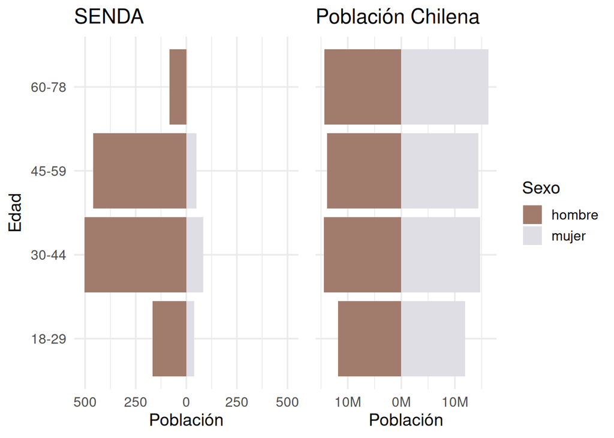

```r
if(grepl("ubuntu",system_r_platform())){
  ggsave(paste0(wdpath,"/cons/_figs/pyramid_congresosp.png"), dpi = 600, width = 9*.9, height=4)
} else {
  ggsave(paste0(wdpath,"/_figs/pyramid_congresosp.png"), dpi = 600, width = 9*.9, height=4)
}
```

## Descriptivos

### RME

```r
sir_tot<- popEpi::sir( coh.data = c_SISTRAT_c3, coh.obs = 'from0to1', coh.pyrs = 'pyrs',
                           ref.data = mx_10x1_banded,
                           ref.rate = 'mx',
                           #print="fot",
                           adjust = c('agegroup','sex'),
                           EAR=T)#Excess Absolute Risks
sir_tot
# SIR (adjusted by agegroup, sex) with 95% confidence intervals (profile)
#
#  Total sir: 7.45 (6.38-8.65)
#  Total observed: 172
#  Total expected: 23.09
#  Total person-years: 5187
#
#    observed expected   pyrs   sir sir.lo sir.hi p_value   EAR
#       <num>    <num>  <num> <num>  <num>  <num>   <num> <num>


sir_tot_fot<- popEpi::sir( coh.data = c_SISTRAT_c3_fot, coh.obs = 'from0to1', coh.pyrs = 'pyrs',
                           ref.data = mx_10x1_banded,
                           ref.rate = 'mx',
                           print="fot",
                           adjust = c('agegroup','sex'),
                           EAR=T)#Excess Absolute Risks
```

Could not solve profile-likelihood. Wald confidence intervals selected.

```r
sir_tot_fot


sir_tot_yr<- popEpi::sir( coh.data = c_SISTRAT_c3_yr, coh.obs = 'from0to1', coh.pyrs = 'pyrs',
                           ref.data = mx_1x1_banded,
                           ref.rate = 'haz',
                           #print="fot",
                           adjust = c('year','agegroup','sex'),
                           EAR=T)#Excess Absolute Risks
sir_tot_yr
# SIR (adjusted by year, agegroup, sex) with 95% confidence intervals (profile)
#
#  Total sir: 8.01 (6.7-9.49)
#  Total observed: 133
#  Total expected: 16.61
#  Total person-years: 4017
#
#    observed expected    pyrs   sir sir.lo sir.hi p_value    EAR
#       <num>    <num>   <num> <num>  <num>  <num>   <num>  <num>
# 1:      133    16.61 4016.98  8.01   6.72   9.45       0 28.975

#Chat GPT
# 3) SMR adjusting for age, sex, year
sir_adj <- popEpi::sir(
  coh.data = lex,
  coh.obs  = "from0to1",
  coh.pyrs = "pyrs",
  ref.data = ref,
  ref.rate = "haz",
  adjust   = c("age","sex","year"),
  EAR      = TRUE
)
sir_adj
# SIR (adjusted by age, sex, year) with 95% confidence intervals (profile)
#
#  Total sir: 9.01 (7.54-10.69)
#  Total observed: 132
#  Total expected: 14.65
#  Total person-years: 4013
#
#    observed expected    pyrs   sir sir.lo sir.hi p_value    EAR
#       <num>    <num>   <num> <num>  <num>  <num>   <num>  <num>
# 1:      132    14.65 4012.87  9.01   7.56  10.64       0 29.244

sir_tot_sex<- popEpi::sir( coh.data = c_SISTRAT_c3, coh.obs = 'from0to1', coh.pyrs = 'pyrs',
                           ref.data = mx_10x1_banded,
                           ref.rate = 'mx',
                           print="sex",
                           adjust = c('agegroup','sex'),
                           EAR=T)#Excess Absolute Risks
sir_tot_sex
# SIR (adjusted by agegroup, sex) with 95% confidence intervals (profile)
# Test for homogeneity: p = 0.018
#
#  Total sir: 7.45 (6.38-8.65)
#  Total observed: 172
#  Total expected: 23.09
#  Total person-years: 5187
#
# Clave <sex>
#       sex observed expected    pyrs   sir sir.lo sir.hi p_value    EAR
#    <char>    <num>    <num>   <num> <num>  <num>  <num>   <num>  <num>
# 1: female       16     1.14  647.15 14.00   8.21  22.03       0 22.958
# 2:   male      156    21.95 4539.55  7.11   6.05   8.28       0 29.530

sir_tot_age<- popEpi::sir( coh.data = c_SISTRAT_c3, coh.obs = 'from0to1', coh.pyrs = 'pyrs',
                           ref.data = mx_10x1_banded,
                           ref.rate = 'mx',
                           print="agegroup",
                           adjust = c('agegroup','sex'),
                           EAR=T)#Excess Absolute Risks
sir_tot_age
# SIR (adjusted by agegroup, sex) with 95% confidence intervals (profile)
# Test for homogeneity: p < 0.001
#
#  Total sir: 7.45 (6.38-8.65)
#  Total observed: 172
#  Total expected: 23.09
#  Total person-years: 5187
#
# Clave <agegroup>
#    agegroup observed expected    pyrs   sir sir.lo sir.hi p_value    EAR
#       <num>    <num>    <num>   <num> <num>  <num>  <num>   <num>  <num>
# 1:       18        6     0.56  621.42 10.78   4.28  21.84       0  8.759
# 2:       30       38     3.51 2160.84 10.81   7.73  14.63       0 15.960
# 3:       45       83     9.59 1953.04  8.65   6.92  10.65       0 37.587
# 4:       60       45     9.43  451.40  4.77   3.51   6.31       0 78.809

sir_tot_yr_sex<- popEpi::sir( coh.data = c_SISTRAT_c3_yr, coh.obs = 'from0to1', coh.pyrs = 'pyrs',
                           ref.data = mx_1x1_banded,
                           ref.rate = 'haz',
                           print="sex",
                           adjust = c('year','agegroup','sex'),
                           EAR=T)#Excess Absolute Risks
sir_tot_yr_sex
# SIR (adjusted by year, agegroup, sex) with 95% confidence intervals (profile)
# Test for homogeneity: p = 0.047
#
#  Total sir: 8.01 (6.7-9.49)
#  Total observed: 133
#  Total expected: 16.61
#  Total person-years: 4017
#
# Clave <sex>
#       sex observed expected    pyrs   sir sir.lo sir.hi p_value    EAR
#    <char>    <num>    <num>   <num> <num>  <num>  <num>   <num>  <num>
# 1: female       12     0.81  497.64 14.76   7.91  24.76       0 22.480
# 2:   male      121    15.80 3519.33  7.66   6.37   9.11       0 29.893

sir_tot_yr_age<- popEpi::sir( coh.data = c_SISTRAT_c3_yr, coh.obs = 'from0to1', coh.pyrs = 'pyrs',
                           ref.data = mx_1x1_banded,
                           ref.rate = 'haz',
                           print="agegroup",
                           adjust = c('year','agegroup','sex'),
                           EAR=T)#Excess Absolute Risks
sir_tot_yr_age
# SIR (adjusted by year, agegroup, sex) with 95% confidence intervals (profile)
# Test for homogeneity: p < 0.001
#
#  Total sir: 8.01 (6.7-9.49)
#  Total observed: 133
#  Total expected: 16.61
#  Total person-years: 4017
#
# Clave <agegroup>
#    agegroup observed expected    pyrs   sir sir.lo sir.hi p_value    EAR
#       <num>    <num>    <num>   <num> <num>  <num>  <num>   <num>  <num>
# 1:       18        5     0.45  512.36 11.17   4.00  24.00       0  8.885
# 2:       30       36     2.66 1684.86 13.55   9.60  18.48       0 19.790
# 3:       45       63     6.98 1486.32  9.03   6.98  11.44       0 37.690
# 4:       60       29     6.53  333.44  4.44   3.02   6.26       0 67.399

sir_adj_sex <- popEpi::sir(
  coh.data = lex,
  coh.obs  = "from0to1",
  coh.pyrs = "pyrs",
  ref.data = ref,
  ref.rate = "haz",
  print= "sex",
  adjust   = c("age","sex","year"),
  EAR      = TRUE
)
sir_adj_sex
```

```
SIR (adjusted by agegroup, sex) with 95% confidence intervals (profile)

 Total sir: 7.45 (6.38-8.65)
 Total observed: 172
 Total expected: 23.08
 Total person-years: 5187


   observed expected   pyrs   sir sir.lo sir.hi p_value    EAR
      <num>    <num>  <num> <num>  <num>  <num>   <num>  <num>
1:      172    23.08 5186.7  7.45   6.39   8.62       0 28.712
SIR (adjusted by agegroup, sex) with 95% confidence intervals (wald)
Test for homogeneity: p = 0.499

 Total sir: 7.45 (6.38-8.65)
 Total observed: 172
 Total expected: 23.08
 Total person-years: 5187


Clave <fot>
      fot observed expected    pyrs   sir sir.lo sir.hi p_value    EAR
    <num>    <num>    <num>   <num> <num>  <num>  <num>   <num>  <num>
1: 0.0000        1     0.21   53.69  4.70   0.66  33.33  0.1220 14.658
2: 0.0386        9     1.14  286.15  7.91   4.11  15.20  0.0000 27.474
3: 0.2465        9     1.34  335.84  6.71   3.49  12.90  0.0000 22.806
4: 0.5000       11     2.56  631.93  4.29   2.38   7.75  0.0000 13.352
5: 1.0000       68     8.81 2041.04  7.72   6.09   9.79  0.0000 29.002
6: 3.0000       53     5.82 1241.56  9.11   6.96  11.93  0.0000 38.004
7: 5.0000       18     2.81  540.00  6.40   4.03  10.15  0.0000 28.122
8: 7.0000        3     0.37   52.87  8.14   2.63  25.25  0.0003 49.775
9: 9.0000        0     0.02    3.60  0.00   0.00    Inf  0.9996 -6.523
SIR (adjusted by year, agegroup, sex) with 95% confidence intervals (profile)

 Total sir: 8.01 (6.7-9.49)
 Total observed: 133
 Total expected: 16.61
 Total person-years: 4017


```

[output cut: 73 more lines]

```
4:       60       29     6.53  333.44  4.44   3.02   6.26       0 67.399
SIR (adjusted by age, sex, year) with 95% confidence intervals (profile)
Test for homogeneity: p = 0.051

 Total sir: 9.01 (7.54-10.69)
 Total observed: 132
 Total expected: 14.65
 Total person-years: 4013


Clave <sex>
      sex observed expected    pyrs   sir sir.lo sir.hi p_value    EAR
   <char>    <num>    <num>   <num> <num>  <num>  <num>   <num>  <num>
1: female       12     0.73  497.64 16.42   8.79  27.53       0 22.645
2:   male      120    13.92 3515.23  8.62   7.17  10.26       0 30.178
```

#### Por causas

```r
# ---------- 0) Helpers ----------
# Robust external-cause detector for DIAG2:
# Accepts V/W/X/Y + two digits, optionally with dot (e.g., X59, X59.9), and up to Y98
is_external_diag2 <- function(code) {
  # Normalize to uppercase text
  code <- as.character(code)
  code <- stringr::str_to_upper(code)
  code <- stringr::str_trim(code)
  # Drop any leading non-letter junk (quotes, punctuation)
  code <- stringr::str_replace(code, "^[^A-Z]+", "")
  # Grab the ICD-10 "category" stem: Letter + 2 digits at the very start
  stem <- stringr::str_match(code, "^([A-Z][0-9]{2})")[, 2]
  # Derive letter and two-digit number
  letter <- substr(stem, 1, 1)
  digits <- suppressWarnings(as.integer(substr(stem, 2, 3)))
  # External if V/W/X OR Y00–Y98 (exclude Y99)
  is_ext <- !is.na(letter) & (
    letter %in% c("V", "W", "X") |
    (letter == "Y" & !is.na(digits) & digits <= 98)
  )
  is_ext[is.na(is_ext)] <- FALSE
  is_ext
}

`%||%` <- function(a, b) if (is.null(a) || length(a)==0 || (length(a)==1 && is.na(a))) b else a

# ---------- 1) National external shares from mortality_first ----------
# Assumes mortality_first has: ano_def (year), sexo (1=Male,2=Female), edad_cant (age, integer), diag2
pop_shares <- mortality_first|>
  dplyr::mutate(
    sex_rec = dplyr::case_when(
      sexo == 1 ~ "male",
      sexo == 2 ~ "female",
      TRUE ~ NA_character_
    ),
    external = dplyr::if_else(is_external_diag2(diag2), 1L, 0L, missing = 0L)
  )|>
  dplyr::filter(!is.na(sex_rec), !is.na(edad_cant), ano_def >= 2011)|>
  dplyr::group_by(sex = sex_rec, age = edad_cant)|>#year = ano_def,
  dplyr::summarise(
    D_ext = sum(external),
    D_all = dplyr::n(),
    .groups = "drop"
  )|>
  dplyr::mutate(
    share_ext    = dplyr::if_else(D_all > 0, D_ext / D_all, 0),
    share_nonext = 1 - share_ext
  )

# ---------- 3) Build reference hazards for EXTERNAL and NON-EXTERNAL ----------
ref_rates_bin <- mx_10x1_filt2|>
    dplyr::left_join(proy_ine_com_18_78_10_19, by= c("sex"="sex_rec", "Age"="age"))|>
  dplyr::left_join(pop_shares, by = c("sex","Age"="age"))|>#"year",
  dplyr::mutate(
    # Age groups: [18,30), [30,45), [45,60), [60, Inf)
    agegroup = cut(Age, breaks = c(18, 30, 45, 60, Inf), right = FALSE),
    # Handle any missing shares just in case
    share_ext = tidyr::replace_na(share_ext, 0),
    # Single-age external / non-external hazards
    haz_ext_age    = mx * share_ext,
    haz_nonext_age = mx * (1 - share_ext)
  )|>
  dplyr::group_by(sex, agegroup)|>
  dplyr::summarise(
    pop_sum = sum(pop, na.rm = TRUE),
    # Population-weighted hazards (this is what you need)
    haz_ext_weighted    = stats::weighted.mean(haz_ext_age,    w = pop, na.rm = TRUE),
    haz_nonext_weighted = stats::weighted.mean(haz_nonext_age, w = pop, na.rm = TRUE),
    # Unweighted means (optional, for reference)
    haz_ext_unweighted    = mean(haz_ext_age,    na.rm = TRUE),
    haz_nonext_unweighted = mean(haz_nonext_age, na.rm = TRUE),
    .groups = "drop")|>
  dplyr::mutate(
    # Order output like the example
    sex = factor(sex, levels = c("male", "female")))|>
  dplyr::arrange(sex, agegroup)|>
  # Round to 8 decimals to match the display you saw
  dplyr::mutate(dplyr::across(dplyr::starts_with("haz_"), ~ round(.x, 8)))

# Two ref tables in long form (one row per stratum per cause-bin)
ref_ext <- dplyr::select(ref_rates_bin, sex, agegroup, haz = haz_ext_weighted)#year,
ref_nonext <- dplyr::select(ref_rates_bin, sex, agegroup, haz = haz_nonext_weighted)#year,

pop_w_icd10_cause_hazards <- tribble(
  ~sex,    ~age_group, ~haz_ext,     ~haz_nonext,
  "male",   "[18,30)",  0.00064637,   0.00033186,
  "male",   "[30,45)",  0.00077019,   0.00099592,
  "male",   "[45,60)",  0.00086709,   0.00430851,
  "male",   "[60,Inf)", 0.00114167,   0.02007774,
  "female", "[18,30)",  0.00012966,   0.00021807,
  "female", "[30,45)",  0.00013432,   0.00063576,
  "female", "[45,60)",  0.00015961,   0.00261771,
  "female", "[60,Inf)", 0.00029236,   0.01275161
)

# ---------- 4) Cohort Lexis (EXTERNAL / NON-EXTERNAL) ----------
# Assumes:
# - clean_df has: hash_key, birth_date_rec, disch_date_rec6, death_date_rec, sexo (1/2)
# - mortality_deduplicated has: hashkey (joining key), diag2 (ICD-10), etc.
# We join death causes to the cohort and define external vs non-external deaths.

cohort_base <- CONS_C3_mod_c_a2|>
  dplyr::mutate(
    sex = dplyr::case_when(
      sexo == "hombre" ~ "male",
      sexo == "mujer" ~ "female",
      TRUE ~ NA_character_))|>
  dplyr::left_join(
    mortality_first|>
      dplyr::transmute(
        hashkey,
        diag2,
        external = dplyr::if_else(is_external_diag2(diag2), 1L, 0L, missing = 0L)
      ),
    by = c("HASH_KEY" = "hashkey")
  )|>
  dplyr::mutate(
    died = !is.na(def_date)                      # 1 si murió, 0 si no
  )

# External deaths as events
cohort_ext_ag <- popEpi::lexpand(
  data   = cohort_base,
  birth  = birth_date,
  entry  = fecha_ingreso_a_tratamiento,
  exit   = def_date_na,
  status = died & external == 1L,  # event if external death
  breaks = list(
    #per = seq(2011, 2021, by = 1),
    age = c(18, 30, 45, 60, Inf)
  ),
  aggre  = list(agegroup = age, sex = sex)#year = per,
)|>
  dplyr::mutate(
    sex      = factor(sex, levels = c("male","female")),
    agegroup = cut(agegroup, breaks = c(18, 30, 45, 60, Inf), right = FALSE)
  )|>
  dplyr::group_by(agegroup, sex)|> #year,
  dplyr::summarise(
    pyrs     = sum(pyrs),
    from0to1 = sum(from0to1),
    .groups  = "drop"
  )

# Non-external deaths as events (death occurred AND not external)
cohort_nonext_ag <- popEpi::lexpand(
  data   = cohort_base,
  birth  = birth_date,
  entry  = fecha_ingreso_a_tratamiento,
  exit   = def_date_na,
  status = died & external == 0L,  # event if external death
  breaks = list(
    #per = seq(2011, 2021, by = 1),
    age = c(18, 30, 45, 60, Inf)
  ),
  aggre  = list(agegroup = age, sex = sex) #year = per,
)|>
  dplyr::mutate(
    sex      = factor(sex, levels = c("male","female")),
    agegroup = cut(agegroup, breaks = c(18, 30, 45, 60, Inf), right = FALSE)
  )|>
  dplyr::group_by(agegroup, sex)|>#year,
  dplyr::summarise(
    pyrs     = sum(pyrs),
    from0to1 = sum(from0to1),
    .groups  = "drop"
  )

# ---------- 5) SIR (RME) for external and non-external ----------
sir_external <- popEpi::sir(
  coh.data = cohort_ext_ag,
  coh.obs  = "from0to1",
  coh.pyrs = "pyrs",
  ref.data = ref_ext,
  ref.rate = "haz",
  adjust   = c("agegroup","sex"),
  EAR      = TRUE
)

sir_nonexternal <- popEpi::sir(
  coh.data = cohort_nonext_ag,
  coh.obs  = "from0to1",
  coh.pyrs = "pyrs",
  ref.data = ref_nonext,
  ref.rate = "haz",
  adjust   = c("agegroup","sex"),
  EAR      = TRUE
)

# Inspect results
sir_external
# SIR (adjusted by agegroup, sex) with 95% confidence intervals (profile)
#
#  Total sir: 7.11 (5.97-8.41)
#  Total observed: 137
#  Total expected: 19.26
#  Total person-years: 5187
#
#    observed expected   pyrs   sir sir.lo sir.hi p_value    EAR
#       <num>    <num>  <num> <num>  <num>  <num>   <num>  <num>
# 1:      137    19.26 5186.7  7.11   5.99   8.37       0 22.699
sir_nonexternal
# SIR (adjusted by agegroup, sex) with 95% confidence intervals (profile)
#
#  Total sir: 7.45 (6.38-8.65)
#  Total observed: 172
#  Total expected: 23.09
#  Total person-years: 5187
#
#    observed expected   pyrs   sir sir.lo sir.hi p_value   EAR
#       <num>    <num>  <num> <num>  <num>  <num>   <num> <num>
# 1:      172    23.09 5186.7  7.45   6.39   8.62       0 28.71
```

```
SIR (adjusted by agegroup, sex) with 95% confidence intervals (profile)

 Total sir: 9.03 (6.29-12.55)
 Total observed: 35
 Total expected: 3.88
 Total person-years: 5187


   observed expected   pyrs   sir sir.lo sir.hi p_value   EAR
      <num>    <num>  <num> <num>  <num>  <num>   <num> <num>
1:       35     3.88 5186.7  9.03   6.36  12.36       0     6
SIR (adjusted by agegroup, sex) with 95% confidence intervals (profile)

 Total sir: 7.11 (5.97-8.41)
 Total observed: 137
 Total expected: 19.26
 Total person-years: 5187


   observed expected   pyrs   sir sir.lo sir.hi p_value    EAR
      <num>    <num>  <num> <num>  <num>  <num>   <num>  <num>
1:      137    19.26 5186.7  7.11   5.99   8.37       0 22.699
```

#### Resumen

```r
cbind.data.frame(res= c("Total ajustado por grupos de edad y sexo", "Total ajustado por grupos de edad, sexo y año calendario", "Total ajustado por edad, sexo y año calendario", "Total ajustado por grupos de edad y sexo, por causas", "", "Desagregado por edad, ajustando por sexo", rep("",3), "Desagregado por edad, ajustando por sexo y año calendario", rep("",3), "Desagregado por sexo, ajustando por grupo de edad", "", "Desagregado por sexo, ajustando por grupo de edad y año calendario", "", "Desagregado por sexo, ajustando por edad y año calendario", ""),
rbind.data.frame(
smr_print(sir_tot),
smr_print(sir_tot_yr),
smr_print(sir_adj),
smr_print(sir_external, "externas"),
smr_print(sir_nonexternal, "no-externas"),
#"Desagregado por edad, ajustado por sexo"
smr_print(sir_tot_age, c("18-29", "30-44", "45-59", "60-78")),
smr_print(sir_tot_yr_age, c("18-29", "30-44", "45-59", "60-78")),
smr_print(sir_tot_sex, c("Mujeres", "Hombres")),
smr_print(sir_tot_yr_sex, c("Mujeres", "Hombres")),
smr_print(sir_adj_sex, c("Mujeres", "Hombres"))
))|>
   (\(df) {
    df ->> smr_resumen
    df
  })()|>
  dplyr::select(-EAR)|>
  knitr::kable(caption= "Exceso de mortalidad, por edad y sexo", col.names= c("Criterio","Categoría", "Observado", "Esperado", "Años-persona", "SMR"))
#Excess Absolute Risks
# \frac{observed - expected}{person years} \times 1000
```

Exceso de mortalidad, por edad y sexo

[output not shown]

```r
# Parse SMR to get rme, lo, hi
smr_resumen <- smr_resumen %>%
  mutate(
    rme = as.numeric(sub("\\s*\\(.*", "", SMR)),
    lo = as.numeric(sub(".*\\((.*)–.*\\)", "\\1", SMR)),
    hi = as.numeric(sub(".*–(.*)\\)", "\\1", SMR))
  )

# Assign sections
sections_order <- c(
  "Totales",
  "Por causas (aj. por sexo y edad)",
  "Edad (aj. por sexo)",
  "Edad (aj. por sexo y año cal.)",
  "Sexo (aj. por grupo de edad)",
  "Sexo (aj. por grupo de edad y año cal.)",
  "Sexo (aj. por edad y año cal.)"
)

# Invert order so Totales are at top
sections_order <- rev(sections_order)

# Manually assign sections (adjust based on data)
smr_resumen$section <- c(
  "Totales", "Totales", "Totales",
  "Por causas (aj. por sexo y edad)", "Por causas (aj. por sexo y edad)",
  "Edad (aj. por sexo)", "Edad (aj. por sexo)", "Edad (aj. por sexo)", "Edad (aj. por sexo)",
  "Edad (aj. por sexo y año cal.)", "Edad (aj. por sexo y año cal.)", "Edad (aj. por sexo y año cal.)", "Edad (aj. por sexo y año cal.)",
  "Sexo (aj. por grupo de edad)", "Sexo (aj. por grupo de edad)",
  "Sexo (aj. por grupo de edad y año cal.)", "Sexo (aj. por grupo de edad y año cal.)",
  "Sexo (aj. por edad y año cal.)", "Sexo (aj. por edad y año cal.)"
)

# Create label
smr_resumen <- smr_resumen %>%
  mutate(label = ifelse(!is.na(total), total, res))

# Create display
display_list <- list()
y <- 0
for (sec in sections_order) {
  header <- tibble(section = sec, label = NA_character_, obs = NA_real_, py = NA_real_, exp = NA_real_,
                   rme = NA_real_, lo = NA_real_, hi = NA_real_, is_header = TRUE, y = y)
  display_list <- append(display_list, list(header))
  y <- y + 1

  items <- smr_resumen %>% filter(section == sec)
  if (nrow(items) > 0) {
    items <- items %>% mutate(is_header = FALSE, y = seq(y, by = 1, length.out = n()))
    display_list <- append(display_list, list(items))
    y <- y + nrow(items)
  }
  y <- y + 0.2
}
display <- bind_rows(display_list)
df_plot  <- display %>% dplyr::filter(!is_header)
headers  <- display %>% dplyr::filter(is_header) %>% dplyr::arrange(y)

# Colors
section_cols <- c(
  "Totales" = "#0F4C5C70",
  "Por causas" = "#0F4C5C80",
  "Edad (aj. por sexo)" = "#5FA9B380",
  "Edad (aj. por sexo y año cal.)" = "#A17C6C80",
  "Sexo (aj. por grupo de edad)" = "#D2A899",
  "Sexo (aj. por grupo de edad y año cal.)" = "#906F0080",
  "Sexo (aj. por edad y año cal.)" = "#52770080"
)

# Calculate limits, start from 0.5
min_lo <- min(df_plot$lo, na.rm = TRUE)
max_hi <- max(df_plot$hi, na.rm = TRUE)
xmin <- 0.5  # Force start at 0.5
xmax <- exp(log(max_hi) + 0.0 * (log(max_hi) - log(min_lo)))

# Rects
rects <- headers %>%
  transmute(
    section,
    ymin = y + 0.4,
    ymax = lead(y) - 0.4
  )
rects$ymax[is.na(rects$ymax)] <- max(display$y, na.rm = TRUE) + 0.6
rects <- rects %>%
  mutate(xmin = xmin * 1.005,
         xmax = xmax / 1.005)

# Labels position (moved left)
x_left_lab <- xmin * 0.5  # Moved further left

cap_h <- 0.25

p <- ggplot() +
  geom_rect(data = rects,
            aes(xmin = xmin, xmax = xmax, ymin = ymin, ymax = ymax),
            inherit.aes = FALSE, fill = "#f7f7f7", color = NA, alpha = 0.6) +
  geom_vline(xintercept = 1, linetype = "dashed", color = "#444444", linewidth = 0.5) +

  geom_segment(data = df_plot,
               aes(x = lo, xend = hi, y = y, yend = y, color = section),
               linewidth = 0.9) +
  geom_segment(data = df_plot,
               aes(x = lo, xend = lo, y = y - cap_h, yend = y + cap_h, color = section),
               linewidth = 0.9) +
  geom_segment(data = df_plot,
               aes(x = hi, xend = hi, y = y - cap_h, yend = y + cap_h, color = section),
               linewidth = 0.9) +

  geom_point(data = df_plot,
             aes(x = rme, y = y, fill = section, color = section),
             shape = 22, size=3,stroke = 0.6) +

  # Label over point with RME to 1 decimal, larger size
  geom_text(data = df_plot,
            aes(x = rme, y = y + 0.3, label = sprintf("%.1f", rme)),
            size = 4, color = "black", hjust = 0.5, vjust = 0) +

  geom_text(data = df_plot,
            aes(x = x_left_lab-.25, y = y, label = paste0("  ", label)),
            hjust = 0, vjust = 0.5, size = 3.6, color = "#222222", inherit.aes = FALSE) +

  geom_text(data = left_join(headers, rects[, c("section", "ymax")], by = "section") %>% mutate(y = ymax + .4),
            aes(x = x_left_lab-.25, y = y, label = section),
            hjust = 0, vjust = 0.5, fontface = "bold", size = 4.0, inherit.aes = FALSE) +

  scale_color_manual(values = section_cols, name = "Sección") +
  scale_fill_manual(values = section_cols, guide = "none") +
  #scale_size(range = c(2.6, 6.2), guide = "none") +

  scale_x_continuous(
    trans = scales::log_trans(base = exp(1)),
    breaks = c(0.5, 1, 2, 5, 10, 20, 50),
    labels = function(x) format(x, big.mark = ".", decimal.mark = ",", trim = TRUE),
    expand = ggplot2::expansion(mult = c(0.3, 0.0))  # No expansion
  ) +
  coord_cartesian(xlim = c(0.5, xmax)) +  # Force xlim from 0.5
  labs(
    title = NULL,
    subtitle = NULL,
    x = "RME (IC 95%), escala logarítmica",
    y = NULL
  ) +
  theme_minimal(base_size = 15) +
  theme(
    panel.grid.major.y = element_blank(),
    panel.grid.minor = element_blank(),
    axis.text.y = element_blank(),
    axis.title.y = element_blank(),
    plot.title.position = "plot",
    legend.position = "none"
  )

print(p)
```

Warning in scale_x_continuous(trans = scales::log_trans(base = exp(1)), : log-2.718282 transformation introduced infinite values. log-2.718282 transformation introduced infinite values.

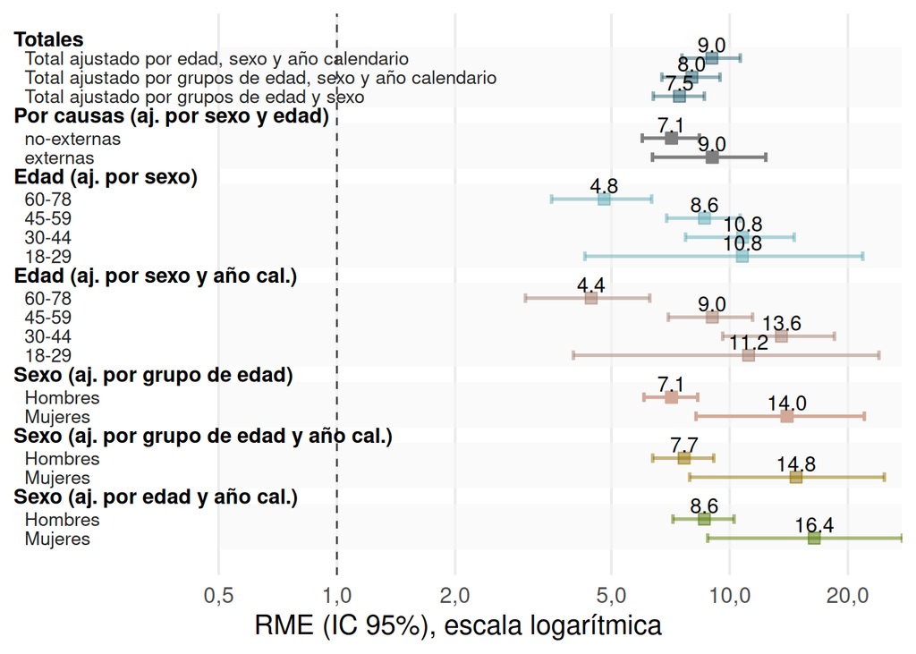

```r
# Exportar si quieres:
ggsave("forestplot_RME_log.png", p, dpi = 600)
```

Saving 7 x 5 in image

Warning in scale_x_continuous(trans = scales::log_trans(base = exp(1)), : log-2.718282 transformation introduced infinite values. log-2.718282 transformation introduced infinite values.

```r
ggsave("forestplot_RME_log.svg", p, dpi = 600)
```

Saving 7 x 5 in image

Warning in scale_x_continuous(trans = scales::log_trans(base = exp(1)), : log-2.718282 transformation introduced infinite values. log-2.718282 transformation introduced infinite values.

### Mapa

```r
# install.packages(c("dplyr","sf","geodata","ggplot2","stringi","tidyr")) # if needed

normalize_region <- function(x) {
  x |>
    stringr::str_to_lower() |>
    stringr::str_replace_all("á", "a") |>
    stringr::str_replace_all("é", "e") |>
    stringr::str_replace_all("í", "i") |>
    stringr::str_replace_all("ó", "o") |>
    stringr::str_replace_all("ú", "u") |>
    stringr::str_replace_all("’|'", "") |>
    stringr::str_replace_all("libertador general bernardo o.?hi.*", "libertador general bernardo ohiggins") |>
    stringr::str_replace_all("santiago metropolitan.*", "metropolitana de santiago") |>
    stringr::str_replace_all("araucania$", "la araucania$") |>
    stringr::str_replace_all("magallanes y antartica chilena", "magallanes y de la antartica chilena") |>
    stringr::str_replace_all("bio-?bio", "biobio") |>
    stringr::str_trim()
}

master_regions <- tibble::tibble(
  cut_code = c("15", "01", "02", "03", "04", "05", "06", "07", "08", "14", "09", "10", "11", "12", "13", "16"),
  roman_code = c("XV", "I", "II", "III", "IV", "V", "VI", "VII", "VIII", "XIV", "IX", "X", "XI", "XII", "RM", "XVI"),
  # Full official names from https://es.wikipedia.org/wiki/Regiones_de_Chile
  # (as of 2024, including Ñuble as 16th region)
  official_name = c("Arica y Parinacota", "Tarapacá", "Antofagasta", "Atacama", "Coquimbo", "Valparaíso",
                    "Libertador General Bernardo O'Higgins", "Maule", "Biobío", "Los Ríos", "La Araucanía",
                    "Los Lagos", "Aysén del General Carlos Ibáñez del Campo",
                    "Magallanes y de la Antártica Chilena", "Metropolitana de Santiago", "Ñuble"),
  # This is our key for matching: lowercase, no accents, simple keywords
  clean_name = c("arica parinacota", "tarapaca", "antofagasta", "atacama", "coquimbo", "valparaiso",
                 "ohiggins", "maule", "biobio", "los rios", "araucania", "los lagos", "aysen",
                 "magallanes", "metropolitana santiago", "nuble")
  )
# 1) Region-level counts from your data
#    Choose which event definition to use:
#    - def_date-based (non-missing death date)
#    - status-based (status == 1)
reg_counts <- CONS_C3_mod_c_a2|>
  dplyr::mutate(
    region_clean = to_ascii_lower(region_del_centro),
    # remove leading "de"/"del"
    region_clean = gsub("^del\\s+", "", region_clean),
    region_clean = gsub("^de\\s+", "", region_clean),
    # specific recodes to align with shapefile names
    region_clean = dplyr::recode(
      region_clean,
      "bio-bio" = "biobio",
      "metropolitana" = "metropolitana de santiago",
      "magallanes y la antartica chilena" = "magallanes",
      "metropolitana de santiago" = "metropolitana santiago",
      "libertador general bernardo ohiggins"="ohiggins",
      "la araucania"="araucania",
      "arica y parinacota"="arica parinacota",
      .default = region_clean
    ),
    death_defdate = !is.na(def_date),
    death_status  = (!is.na(status) & status == 1)
  )|>
  dplyr::group_by(region_clean)|>
  dplyr::summarise(
    n               = n(),
    deaths_defdate  = sum(death_defdate, na.rm = TRUE),
    py   = sum(timesurv_adm,  na.rm = TRUE),
    .groups = "drop")|>
  dplyr::mutate(
    region_clean = stringr::str_to_lower(region_clean)
  )|>
  dplyr::left_join(master_regions, by= c("region_clean"="clean_name"))|>
  dplyr::mutate(roman_code= ifelse(grepl("metro", region_clean), "RM", roman_code))


# 2) Get region shapefile (GADM level 1) and normalize names
reg_terra <- geodata::gadm(country = "CHL", level = 1, path = tempdir())
reg_sf <- sf::st_as_sf(reg_terra)

# 3) Join your counts to the regions, compute rates
reg_sf <- reg_sf%>%
  dplyr::left_join(reg_counts, by = c("CC_1"="roman_code")) %>%
  dplyr::mutate(
    n              = tidyr::replace_na(n, 0L),
    deaths_defdate = tidyr::replace_na(deaths_defdate, 0L),
    rate_defdate   = if_else(n > 0, deaths_defdate / n, NA_real_),
    rate_status    = if_else(py > 0, deaths_defdate  / py, NA_real_)
  )#

# Optional: check for unmatched region names from your data
unmatched <- reg_counts %>%
  dplyr::anti_join(reg_sf %>% sf::st_drop_geometry() %>% dplyr::select(CC_1), by = c("roman_code"="CC_1"))
print(unmatched)

dark_teal <- "#0F4C5C"  # dark teal (editable)
blanco    <- "#FFFFFF"
a17c6c    <- "#A17C6C"  # warm brown-rose
g052709   <- "#052709"  # verde bosque muy oscuro
c5fa9b3   <- "#5FA9B3"  # teal claro
d2a899    <- "#D2A899"  # durazno/arena
o906f00   <- "#906F00"  # ocre/mostaza
d_edee4   <- "#DEDEE4"  # gris lavanda claro
sequential_cool = grDevices::colorRampPalette(
    c(g052709, dark_teal, c5fa9b3, d_edee4, blanco)
)
andal_teal_warm <- c(
  dark_teal = "#052709",
  teal_accent = "#5FA9B3",
  warm_mid = "#A17C6C",
  warm_light = "#D2A899",
  earth_gold = "#906F00",
  olive = "#527700",
  neutral = "#DEDEE4",
  white = "#FFFFFF"
)
cont_palette <- c(
  "#052709", # dark teal
  "#5FA9B3", # teal accent
  "#A17C6C", # warm mid
  "#D2A899", # warm light
  "#906F00", # earth gold
  "#527700"  # olive
)

# 4) Plot: deaths by region (based on def_date)

# make sure your sf is in long/lat (WGS84)
reg_sf <- sf::st_transform(reg_sf, crs = 4326)

# continental Chile bbox (adjust if needed)
xlim_cont <- c(-76, -66.4)   # longitudes: west = negative
ylim_cont <- c(-56, -17)     # latitudes: south = negative

p_tratados <- ggplot(reg_sf) +
  geom_sf(aes(fill = n), color = "gray40",  size = 0.1) +
  coord_sf(xlim = xlim_cont, ylim = ylim_cont, expand = FALSE) +
  #scale_fill_viridis_c(option = "plasma", direction = -1, na.value = "grey90",  name = "Fallecimientos") +
  scale_fill_gradientn(colors = rev(c(g052709, dark_teal, c5fa9b3, d_edee4, blanco)), na.value = "#DEDEE4", name = "Tratados") +
  theme_void() +
  labs(
    #title = "Fallecimientos en la cohorte por región",
    #subtitle = "Based on non-missing def_date",
  ) +
  theme_void(base_size = 15) +
  xlim(c(-74,-66.4))+
  theme(legend.position = "left")

p_deaths <- ggplot(reg_sf) +
  geom_sf(aes(fill = deaths_defdate), color = "gray40",  size = 0.1) +
  coord_sf(xlim = xlim_cont, ylim = ylim_cont, expand = FALSE) +
  #scale_fill_viridis_c(option = "plasma", direction = -1, na.value = "grey90",  name = "Fallecimientos") +
  scale_fill_gradientn(colors = rev(c(g052709, dark_teal, c5fa9b3, d_edee4, blanco)), na.value = "#DEDEE4", name = "Fallecimientos") +
  theme_void() +
  # labs(
  #   #title = "Fallecimientos en la cohorte por región",
  #   #subtitle = "Based on non-missing def_date",
  #   caption = "Recuentos reflejan la cohorte,\nno la mortalidad poblacional"
  # ) +
  theme_void(base_size = 15) +
  xlim(c(-74,-66.4))+
  theme(legend.position = "left")

# Print plots
cowplot::plot_grid(
  p_tratados +
  coord_sf(expand = FALSE) +
  theme(
    plot.margin = margin(0, 0, 0, 0),
    legend.spacing = unit(0.1, "lines"),
    legend.key.size = unit(0.6, "lines")
  ), p_deaths +
  coord_sf(expand = FALSE) +
  theme(
    plot.margin = margin(0, 0, 0, 0),
    legend.spacing = unit(0.1, "lines"),
    legend.key.size = unit(0.6, "lines")
  ),
  nrow = 1,                # o nrow = 1 según tu disposición
  align = "v",             # o "h" para horizontal
  rel_heights = c(1, 1),# ajusta proporciones si necesario
  axis = "tblr",           # alinea ejes si aplica
  labels = NULL,           # evita espacio extra por etiquetas
  label_size = 0,          # si usas labels, reduce tamaño
  label_x = 0, label_y = 1,# controla posición de etiquetas
  vjust = 1, hjust = 0,    # controla alineación vertical/horizontal
  scale = c(0.99, .99) # reduce tamaño relativo de cada plot
)
```

Coordinate system already present. ℹ Adding new coordinate system, which will replace the existing one. Coordinate system already present. ℹ Adding new coordinate system, which will replace the existing one.

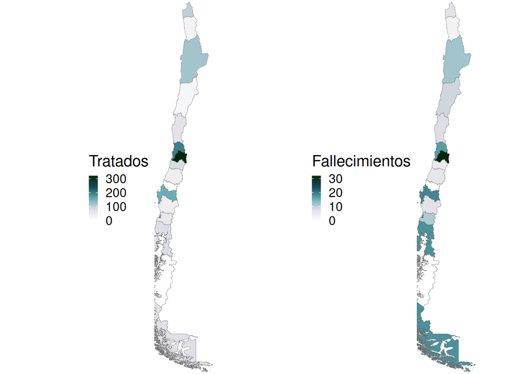

```r
if(grepl("ubuntu",system_r_platform())){
  ggsave(paste0("map.png"), dpi = 600, scale=1)
} else{
  ggsave(paste0("map.png"), dpi = 600, scale=1)
}
```

Saving 7 x 5 in image

```r
# If you prefer status==1 instead of def_date, replace 'deaths_defdate' and 'rate_defdate'
# with 'deaths_status' and 'rate_status' in the fill aesthetics/titles.

reg_counts |> mutate(rate=deaths_defdate/py) |> arrange(desc(rate)) |> mutate(rate_p_mil= rate*1000, prop=(deaths_defdate/n)*100) |>  knitr::kable("markdown", digits=1)
```

[output not shown]

| region_clean | n | deaths_defdate | py | cut_code | roman_code | official_name | rate | rate_p_mil | prop |
| --- | --- | --- | --- | --- | --- | --- | --- | --- | --- |
| atacama | 22 | 9 | 96.1 | 03 | III | Atacama | 0.1 | 93.6 | 40.9 |
| araucania | 42 | 7 | 76.0 | 09 | IX | La Araucanía | 0.1 | 92.1 | 16.7 |
| los lagos | 81 | 18 | 219.6 | 10 | X | Los Lagos | 0.1 | 82.0 | 22.2 |
| magallanes | 78 | 18 | 276.7 | 12 | XII | Magallanes y de la Antártica Chilena | 0.1 | 65.1 | 23.1 |
| los rios | 56 | 11 | 195.2 | 14 | XIV | Los Ríos | 0.1 | 56.3 | 19.6 |
| coquimbo | 68 | 8 | 200.5 | 04 | IV | Coquimbo | 0.0 | 39.9 | 11.8 |
| biobio | 154 | 19 | 551.2 | 08 | VIII | Biobío | 0.0 | 34.5 | 12.3 |
| antofagasta | 119 | 12 | 414.0 | 02 | II | Antofagasta | 0.0 | 29.0 | 10.1 |
| maule | 41 | 6 | 220.3 | 07 | VII | Maule | 0.0 | 27.2 | 14.6 |
| metropolitana de santiago | 321 | 32 | 1251.6 |  | RM |  | 0.0 | 25.6 | 10.0 |
| valparaiso | 196 | 17 | 765.6 | 05 | V | Valparaíso | 0.0 | 22.2 | 8.7 |
| arica parinacota | 102 | 7 | 427.2 | 15 | XV | Arica y Parinacota | 0.0 | 16.4 | 6.9 |
| ohiggins | 82 | 5 | 306.4 | 06 | VI | Libertador General Bernardo O’Higgins | 0.0 | 16.3 | 6.1 |
| tarapaca | 29 | 3 | 186.5 | 01 | I | Tarapacá | 0.0 | 16.1 | 10.3 |

### Resumen

```r
table_one_print |>
    DT::datatable(filter = 'top',
        caption = htmltools::tags$caption(
            style = 'caption-side: top; text-align: left;',
            htmltools::tags$b('Descriptivos')),#colnames = c('Term', 'Estimate', 'CI Low', 'CI High', 'VIF', 'Df', 'GVIF Adj.')
        rownames = FALSE,
        options = list(
            pageLength = 25,
            autoWidth = TRUE,
            scrollX = TRUE,
            dom = 'tip',
            initComplete = htmlwidgets::JS(
                "function(settings, json) {
           $(this.api().tables().body()).css({
             'font-family': 'Helvetica Neue',
             'font-size': '70%',
             'white-space': 'nowrap',
             'line-height': '.9em'
           });
         }"
            )))
```

| "level" | "Overall" | "0" | "1" | "p" | "test" | "Missing" |
| --- | --- | --- | --- | --- | --- | --- |
|  | 1,391 | 1,219 | 172 |  |  |  |
| de antofagasta | 119 (8.6) | 107 (8.8) | 12 (7.0) | &lt;0.001 |  | 0.0 |
| de arica y parinacota | 102 (7.3) | 95 (7.8) | 7 (4.1) |  |  |  |
| de atacama | 22 (1.6) | 13 (1.1) | 9 (5.2) |  |  |  |
| de coquimbo | 68 (4.9) | 60 (4.9) | 8 (4.7) |  |  |  |
| de la araucania | 42 (3.0) | 35 (2.9) | 7 (4.1) |  |  |  |
| de los lagos | 81 (5.8) | 63 (5.2) | 18 (10.5) |  |  |  |
| de los rios | 56 (4.0) | 45 (3.7) | 11 (6.4) |  |  |  |
| de magallanes y la antartica chilena | 78 (5.6) | 60 (4.9) | 18 (10.5) |  |  |  |
| de tarapaca | 29 (2.1) | 26 (2.1) | 3 (1.7) |  |  |  |

[output cut: 165 more lines]

# Supervivencia relativa

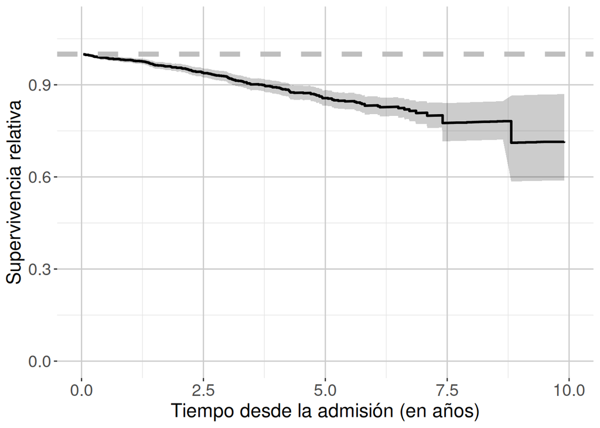

```r
dat_rs <- CONS_C3_mod_c_a2 %>%
  filter(dayssurv_adm >= 0) %>%
  mutate(
    # Edad en días (entero)
    age_days = as.integer(floor(age_admdate_num * 365.2425)),
    # Sexo como 1/2 (1=male, 2=female) según el ratetable
    sex_rs = case_when(
      sex %in% c("male", 1, "1", "hombre", "Hombre")  ~ 1L,
      sex %in% c("female", 2, "2", "mujer", "Mujer")  ~ 2L,
      TRUE ~ NA_integer_
    ),
    # Año como FECHA:
    year_date =fecha_ingreso_a_tratamiento
  )
# 3) Relative survival (Hakulinen)
dSR1_SC <- relsurv::rs.surv(
  Surv(dayssurv_adm, status) ~ 1,
  data      = dat_rs,
  ratetable = rt,
  method    = "hakulinen",
  rmap      = list(age = age_days, sex = sex_rs, year = year_date)
)

#This article shows that if the follow-up of the cohort is less than 10 years,
#any of these methods should give similar results. However, the Hakulinen method is preferred,
#since it accounts for heterogeneity due to potential withdrawals.
#https://scielo.isciii.es/scielo.php?script=sci_arttext&pid=S0213-91112006000400012



surv_data_sc <- data.frame(
  time = dSR1_SC$time,                # Tiempo
  surv = dSR1_SC$surv,                # Supervivencia
  lower = dSR1_SC$lower,              # Límite inferior del IC
  upper = dSR1_SC$upper               # Límite superior del IC
) %>%
  mutate(group = "Total")

summary(dSR1_SC, times = c(1, 3, 5, 7)*365.241, scale = 365.241, area = TRUE)

ggplot(surv_data_sc, aes(x = time/365.25, y = surv)) +
  geom_step(linewidth = 1) +  # Curva de supervivencia
  geom_ribbon(aes(ymin = lower, ymax = upper), fill= "black", alpha = 0.2) +  # Intervalos de confianza
  labs(
    x = "Tiempo desde la admisión (en años)",
    y = "Supervivencia relativa",
  ) +
  coord_cartesian(xlim = c(0, 10), ylim= c(0, 1.10)) +
  geom_hline(yintercept = 1, linewidth = 2, linetype = "dashed", color = "gray") +
  #theme_minimal()  +
  theme_sjPlot_manual()+
  theme(
    plot.title = element_text(size = 20),       # Tamaño del título del gráfico
    axis.title.x = element_text(size = 16),    # Tamaño del título del eje x
    axis.title.y = element_text(size = 16),    # Tamaño del título del eje y
    axis.text.x = element_text(size = 14),     # Tamaño de las etiquetas del eje x
    axis.text.y = element_text(size = 14)      # Tamaño de las etiquetas del eje y
  )
```

```r
if(grepl("ubuntu",system_r_platform())){
  ggsave(paste0(wdpath,"/_figs/relsurv_gral.png"), dpi = 600, scale=1)
} else{
  ggsave(paste0("_figs/relsurv_gral.png"), dpi = 600, scale=1)
}
```

Saving 7 x 5 in image

```r
# Crear análisis separado por grupos temporales
results <- list()

time_intervals <- list(
  "0-90" = c(0, 90),
  "90-365" = c(90, 1*365.241),
  "365-730" = c(1, 3)*365.241,
  "730-1825" = c(3, 5)*365.241,
  "1825-2557" = c(5, 7)*365.241
)

for (interval_name in names(time_intervals)) {
  interval <- time_intervals[[interval_name]]

  # Filtrar datos para este intervalo
  temp_data <- dat_rs[dat_rs$dayssurv_adm >= interval[1] &
                       dat_rs$dayssurv_adm < interval[2], ]

  if (nrow(temp_data) > 0 && sum(temp_data$status) > 0) {
    model <- relsurv::rsadd(
      Surv(dayssurv_adm, status) ~ 1,
      data = temp_data,
      ratetable = rt,
      method = "max.lik",
      rmap = list(age = age_days, sex = sex_rs, year = year_date)
    )
    results[[interval_name]] <- model
  }
}

# Ver resultados
results
```

[output not shown]

[output cut: 22 more lines]

```
n=351


$`1825-2557`

Call: relsurv::rsadd(formula = Surv(dayssurv_adm, status) ~ 1, data = temp_data,
    ratetable = rt, method = "max.lik", rmap = list(age = age_days,
        sex = sex_rs, year = year_date))


Coefficients:
fu [0,7]
  -5.683

n=360
```

# Session info

```r
#|echo: true
#|error: true
#|message: true
#|paged.print: true
message(paste0("R library: ", Sys.getenv("R_LIBS_USER")))
```

R library: /home/andres/Escritorio/SER2025/renv/library/linux-ubuntu-noble/R-4.4/x86_64-pc-linux-gnu

```r
message(paste0("Date: ",withr::with_locale(new = c('LC_TIME' = 'C'), code =Sys.time())))
```

Date: 2025-10-11 12:24:14.970569

```r
message(paste0("Editor context: ", path))
```

Error: objeto ‘path’ no encontrado

```r
cat("quarto version: "); quarto::quarto_version()
```

```
quarto version:
```

```
[1] '1.7.32'
```

```r
sesion_info <- devtools::session_info()
dplyr::select(
  tibble::as_tibble(sesion_info$packages),
  c(package, loadedversion, source)
)|>
  DT::datatable(filter = 'top', colnames = c('Row number' =1,'Package' = 2, 'Version'= 3),
              caption = htmltools::tags$caption(
        style = 'caption-side: top; text-align: left;',
        '', htmltools::em('R packages')),
      options=list(
initComplete = htmlwidgets::JS(
        "function(settings, json) {",
        "$(this.api().tables().body()).css({
            'font-family': 'Helvetica Neue',
            'font-size': '70%',
            'code-inline-font-size': '15%',
            'white-space': 'nowrap',
            'line-height': '0.75em',
            'min-height': '0.5em'
            });",
        "}")))
```

| Row number | Package | Version | source |
| --- | --- | --- | --- |
| 1 | abind | 1.4-8 | RSPM (R 4.4.0) |
| 2 | backports | 1.5.0 | RSPM (R 4.4.0) |
| 3 | base64enc | 0.1-3 | RSPM (R 4.4.0) |
| 4 | biostat3 | 0.2.3 | RSPM (R 4.4.0) |
| 5 | bpmn | 0.1.0 | Github (bergant/bpmn@628d3efaa27544c221b2fd7f1895301a63b70c49) |
| 6 | broom | 1.0.10 | RSPM (R 4.4.0) |
| 7 | bslib | 0.9.0 | RSPM (R 4.4.0) |
| 8 | cachem | 1.1.0 | RSPM (R 4.4.0) |
| 9 | car | 3.1-3 | RSPM (R 4.4.0) |
| 10 | carData | 3.0-5 | RSPM (R 4.4.0) |

[output cut: 157 more lines]

```r
#|echo: true
#|error: true
#|message: true
#|paged.print: true
#|class-output: center-table

reticulate::py_list_packages()|>
  DT::datatable(filter = 'top', colnames = c('Row number' =1,'Package' = 2, 'Version'= 3),
              caption = htmltools::tags$caption(
        style = 'caption-side: top; text-align: left;',
        '', htmltools::em('Python packages')),
      options=list(
initComplete = htmlwidgets::JS(
        "function(settings, json) {",
        "$(this.api().tables().body()).css({
            'font-family': 'Helvetica Neue',
            'font-size': '70%',
            'code-inline-font-size': '15%',
            'white-space': 'nowrap',
            'line-height': '0.75em',
            'min-height': '0.5em'
            });",
        "}")))
```

| Row number | Package | Version | requirement |
| --- | --- | --- | --- |
| 1 | numpy | 2.3.3 | numpy==2.3.3 |

Save

```r
save.image("congresosp.RData")
#:#:#:#:#:#:#:#:#:#:#:#:#:#:#:#:#:#:#:#:#:#:#:#:#:#:#:#:#:#:#:#:#:#:#:
#:#:#:#:#:#:#:#:#:#:#:#:#:#:#:#:#:#:#:#:#:#:#:#:#:#:#:#:#:#:#:#:#:#:#:
cat("Copy renv lock into cons folder\n")

if (Sys.getenv("RSTUDIO_SESSION_TYPE") == "server" || file.exists("/.dockerenv")) {
  message("Running on RStudio Server or inside Docker. Folder copy skipped.")
} else {
  source_folder <-
  destination_folder <- paste0(wdpath,"cons/renv")
  # Copy the folder recursively
    file.copy(paste0(wdpath,"renv.lock"), paste0(wdpath,"cons/renv.lock"), overwrite = TRUE)
  message("Renv lock copy performed.")
}
```

Renv lock copy performed.

```r
#:#:#:#:#:#:#:#:#:#:#:#:#:#:#:#:#:#:#:#:#:
time_after_dedup2<-Sys.time()

paste0("Time in markdown: ");time_after_dedup2-time_before_dedup2
```

```
Copy renv lock into cons folder
[1] "Time in markdown: "
Time difference of 13.72599 days
```